# Final practice

Antonio Torres Escribano, Jaume Cantallops Comas, Jordi Florit Ensenyat, Josep Gabriel Fornes Reynes and Pau Girón Rodríguez

2025-01-28

## 1. Introduction

Real estate investment is a cornerstone of financial growth, yet it remains a complex and often unpredictable field. Investors frequently struggle to identify profitable opportunities due to the overwhelming number of factors influencing property values, as well as the lack of systematic, data-driven approaches to decision-making.

The primary objective of this research is to determine the key characteristics that should guide investment decisions in residential properties across Portugal. By analyzing patterns within real estate data, this study aims to empower investors to make more informed and strategic choices, reducing the risks associated with traditional methods based on intuition or incomplete information.

To tackle this challenge, the problem has been divided into three specific sub-questions, each contributing to the overall understanding of the problem:

1. Identifying the factors that most influence property prices: What variables, such as location, play the largest role in determining a property’s value?
2. Recognizing high-value property traits: What common characteristics are shared by properties with higher prices, and how can these traits be used to identify similar investment opportunities?
3. Highlighting areas with undervalued properties: Which regions in Portugal have a higher density of properties that are priced below their true market value, offering potential for high returns?

By addressing these questions, this study not only seeks to provide clarity on the drivers of property value but also aims to uncover hidden opportunities in the market. The use of data-driven methodologies ensures that the analysis is objective, reliable, and capable of adapting to the dynamic nature of real estate trends.

Ultimately, this research will serve as a practical guide for investors looking to maximize their returns in the Portuguese housing market, demonstrating the transformative potential of data science in solving real-world problems.

# 2. Exploratory Data Analysis (EDA)

## 2.1 Loading and Inspecting the Dataset

```r
library(visdat)
```

```r
library(tidyr)
library(dplyr)
library(ggplot2)
library(reshape2)
library(ggcorrplot)
library(corrplot)
library(cluster)
```

```r
portugal_data <- read.csv(file = 'portugal_housing.csv')
```

```r
str(portugal_data)
```

```
## 'data.frame':    114623 obs. of  25 variables:
##  $ Price               : num  250000 9500 580000 350000 175000 ...
##  $ District            : chr  "Faro" "Faro" "Faro" "Faro" ...
##  $ City                : chr  "São Brás de Alportel" "Albufeira" "Vila do Bispo" "Portimão" ...
##  $ Town                : chr  "São Brás de Alportel" "Albufeira e Olhos de Água" "Budens" "Portimão" ...
##  $ Type                : chr  "Apartment" "Apartment" "Apartment" "Apartment" ...
##  $ EnergyCertificate   : chr  "A+" "NC" "D" "C" ...
##  $ Floor               : chr  "2nd Floor" "1st Floor" "3rd Floor" "4th Floor" ...
##  $ Lift                : chr  "True" "True" "False" "True" ...
##  $ Parking             : num  1 0 1 0 0 2 3 1 0 0 ...
##  $ HasParking          : chr  "True" "False" "True" "False" ...
##  $ ConstructionYear    : num  NA 1990 2003 1985 1950 ...
##  $ TotalArea           : num  114 27 84 68 78 472 421 15 105 63 ...
##  $ GrossArea           : num  NA NA NA NA NA NA 313 NA 114 NA ...
##  $ PublishDate         : chr  "" "" "" "" ...
##  $ Garage              : chr  "" "" "" "" ...
##  $ Elevator            : chr  "" "" "" "" ...
##  $ ElectricCarsCharging: chr  "" "" "" "" ...
##  $ TotalRooms          : num  2 0 2 2 4 4 7 0 2 1 ...
##  $ NumberOfBedrooms    : num  NA NA NA NA NA NA NA NA NA NA ...
##  $ NumberOfWC          : num  NA NA NA NA NA NA NA NA NA NA ...
##  $ ConservationStatus  : chr  "" "" "" "" ...
##  $ LivingArea          : num  114 27 84 68 78 414 262 15 105 63 ...
##  $ LotSize             : num  NA NA NA NA NA NA NA NA NA NA ...
##  $ BuiltArea           : num  NA NA NA NA NA NA NA NA NA NA ...
##  $ NumberOfBathrooms   : num  2 1 2 1 2 5 NA 0 2 2 ...
```

## 2.2 Missing values

Here we will see how there are columns that, instead of having NA, contain empty values (““).

```r
head(levels(as.factor(portugal_data$Town)))
```

```
## [1] ""                         "A dos Cunhados e Maceira"
## [3] "A dos Francos"            "A dos Negros"
## [5] "Ã\u0081zere"              "Abação e Gémeos"
```

We replace the variables that contain `Ã\u0081zere` with Azere.

```r
portugal_data <- portugal_data %>%
  mutate(Town = if_else(Town == "Ã\u0081zere", "Azere", Town))
```

Then we’ll check the categorical values as factors

```r
levels(as.factor(portugal_data$Type))
```

```
##  [1] ""                    "Apartment"           "Building"
##  [4] "Duplex"              "Estate"              "Farm"
##  [7] "Garage"              "Hotel"               "House"
## [10] "Industrial"          "Investment"          "Land"
## [13] "Manor"               "Mansion"             "Office"
## [16] "Other - Commercial"  "Other - Residential" "Storage"
## [19] "Store"               "Studio"              "Transfer of lease"
## [22] "Warehouse"
```

```r
levels(as.factor(portugal_data$EnergyCertificate))
```

```
##  [1] ""               "A"              "A+"             "B"
##  [5] "B-"             "C"              "D"              "E"
##  [9] "F"              "G"              "NC"             "No Certificate"
## [13] "Not available"
```

```r
levels(as.factor(portugal_data$Floor))
```

```
##  [1] ""                 "1st Floor"        "2nd Floor"        "3rd Floor"
##  [5] "4th Floor"        "5th Floor"        "6th Floor"        "7th Floor"
##  [9] "8th Floor"        "9th Floor"        "Above 10th Floor" "Attic"
## [13] "Basement"         "Basement Level"   "Duplex"           "Ground Floor"
## [17] "Mezzanine"        "Service Floor"    "Top Floor"        "Triplex"
```

```r
levels(as.factor(portugal_data$Lift))
```

```
## [1] ""      "False" "True"
```

```r
levels(as.factor(portugal_data$HasParking))
```

```
## [1] ""      "False" "True"
```

```r
head(levels(as.factor(portugal_data$PublishDate)))
```

```
## [1] ""                        "2018-04-09 06:27:08.827"
## [3] "2018-04-09 06:27:17.653" "2018-10-31 22:08:50.903"
## [5] "2020-08-08 23:02:31.243" "2020-09-18 12:34:58.317"
```

```r
levels(as.factor(portugal_data$Garage))
```

```
## [1] ""      "False" "True"
```

```r
levels(as.factor(portugal_data$Elevator))
```

```
## [1] ""      "False" "True"
```

```r
levels(as.factor(portugal_data$ElectricCarsCharging))
```

```
## [1] ""      "False" "True"
```

```r
levels(as.factor(portugal_data$ConservationStatus))
```

```
## [1] ""                 "Good condition"   "Like new"         "Needs renovation"
## [5] "New"              "Reasonable"       "Used"
```

Instead of having empty values, we will replace these values with NA:

```r
portugal_data$Town[portugal_data$Town == ""] <- NA
summary(as.numeric(as.factor(portugal_data$Town)))
```

```
##    Min. 1st Qu.  Median    Mean 3rd Qu.    Max.    NA's
##       1     502    1081    1065    1620    2237       2
```

```r
portugal_data$Type[portugal_data$Type == ""] <- NA
summary(as.numeric(as.factor(portugal_data$Type)))
```

```
##    Min. 1st Qu.  Median    Mean 3rd Qu.    Max.    NA's
##   1.000   1.000   8.000   7.063  11.000  21.000      16
```

For EnergyCertificate instead of assigning NA to the empty values, we assign ‘No Certificate’, same for the values ‘Not available’ and ‘NC’.

```r
portugal_data$EnergyCertificate[portugal_data$EnergyCertificate == ""] <- "No Certificate"
portugal_data$EnergyCertificate[portugal_data$EnergyCertificate == "Not available"] <- "No Certificate"
portugal_data$EnergyCertificate[portugal_data$EnergyCertificate == "NC"] <- "No Certificate"
summary(as.numeric(as.factor(portugal_data$EnergyCertificate)))
```

```
##    Min. 1st Qu.  Median    Mean 3rd Qu.    Max.
##   1.000   5.000   8.000   7.267  10.000  10.000
```

```r
portugal_data$Floor[portugal_data$Floor == ""] <- NA
summary(as.numeric(as.factor(portugal_data$Floor)))
```

```
##    Min. 1st Qu.  Median    Mean 3rd Qu.    Max.    NA's
##    1.00    2.00    3.00    6.28   15.00   19.00   86694
```

```r
portugal_data$Lift[portugal_data$Lift == ""] <- NA
summary(as.numeric(as.factor(portugal_data$Lift)))
```

```
##    Min. 1st Qu.  Median    Mean 3rd Qu.    Max.    NA's
##    1.00    1.00    1.00    1.25    2.00    2.00   46408
```

```r
portugal_data$HasParking[portugal_data$HasParking == ""] <- NA
summary(as.numeric(as.factor(portugal_data$HasParking)))
```

```
##    Min. 1st Qu.  Median    Mean 3rd Qu.    Max.    NA's
##    1.00    1.00    1.00    1.45    2.00    2.00   46408
```

```r
portugal_data$PublishDate[portugal_data$PublishDate == ""] <- NA
summary(as.numeric(as.factor(portugal_data$PublishDate)))
```

```
##    Min. 1st Qu.  Median    Mean 3rd Qu.    Max.    NA's
##       1    3683    7342    7341   11007   14688   99567
```

```r
portugal_data$Garage[portugal_data$Garage == ""] <- NA
summary(as.numeric(as.factor(portugal_data$Garage)))
```

```
##    Min. 1st Qu.  Median    Mean 3rd Qu.    Max.    NA's
##    1.00    1.00    1.00    1.17    1.00    2.00   68247
```

```r
portugal_data$Elevator[portugal_data$Elevator == ""] <- NA
summary(as.numeric(as.factor(portugal_data$Elevator)))
```

```
##    Min. 1st Qu.  Median    Mean 3rd Qu.    Max.    NA's
##    1.00    1.00    1.00    1.23    1.00    2.00   68247
```

```r
portugal_data$ElectricCarsCharging[portugal_data$ElectricCarsCharging == ""] <- NA
summary(as.numeric(as.factor(portugal_data$ElectricCarsCharging)))
```

```
##    Min. 1st Qu.  Median    Mean 3rd Qu.    Max.    NA's
##    1.00    1.00    1.00    1.09    1.00    2.00   68247
```

```r
portugal_data$ConservationStatus[portugal_data$ConservationStatus == ""] <- NA
summary(as.numeric(as.factor(portugal_data$ConservationStatus)))
```

```
##    Min. 1st Qu.  Median    Mean 3rd Qu.    Max.    NA's
##    1.00    1.00    4.00    3.12    4.00    6.00  101542
```

```r
portugal_data$District <- as.factor(portugal_data$District)
portugal_data$City <- as.factor(portugal_data$City)
portugal_data$Town <- as.factor(portugal_data$Town)
portugal_data$Type <- as.factor(portugal_data$Type)
portugal_data$EnergyCertificate <- as.factor(portugal_data$EnergyCertificate)
portugal_data$Floor <- as.factor(portugal_data$Floor)
portugal_data$Lift <- as.factor(portugal_data$Lift)
portugal_data$HasParking <- as.factor(portugal_data$HasParking)
portugal_data$PublishDate <- as.factor(portugal_data$PublishDate)
portugal_data$Garage <- as.factor(portugal_data$Garage)
portugal_data$Elevator <- as.factor(portugal_data$Elevator)
portugal_data$ElectricCarsCharging <- as.factor(portugal_data$ElectricCarsCharging)
portugal_data$ConservationStatus <- as.factor(portugal_data$ConservationStatus)

summary(portugal_data)
```

```
##      Price              District                    City
##  Min.   :1.000e+02   Lisboa :25719   Lisboa           : 6945
##  1st Qu.:7.800e+04   Porto  :17994   Sintra           : 4502
##  Median :2.000e+05   Braga  : 9924   Vila Nova de Gaia: 3557
##  Mean   :3.666e+05   Setúbal: 9575   Porto            : 3368
##  3rd Qu.:3.900e+05   Faro   : 7717   Cascais          : 2770
##  Max.   :1.380e+09   Coimbra: 6704   Braga            : 2289
##  NA's   :244         (Other):36990   (Other)          :91192
##                                                               Town
##  Albufeira e Olhos de Água                                      :  1330
##  Cascais e Estoril                                              :  1263
##  Cedofeita, Santo Ildefonso, Sé, Miragaia, São Nicolau e Vitória:   933
##  Portimão                                                       :   901
##  Canidelo                                                       :   773
##  (Other)                                                        :109421
##  NA's                                                           :     2
##         Type            EnergyCertificate          Floor          Lift
##  Apartment:37558   No Certificate:52724   Ground Floor: 6973   False:51076
##  House    :31171   C             :13547   1st Floor   : 6038   True :17139
##  Land     :28649   D             :12913   2nd Floor   : 5019   NA's :46408
##  Store    : 4684   E             : 9084   3rd Floor   : 3817
##  Farm     : 3547   A             : 8414   4th Floor   : 1902
##  (Other)  : 8998   F             : 6429   (Other)     : 4180
##  NA's     :   16   (Other)       :11512   NA's        :86694
##     Parking       HasParking    ConstructionYear   TotalArea
##  Min.   :0.0000   False:37370   Min.   :1900     Min.   :-7.196e+06
##  1st Qu.:0.0000   True :30845   1st Qu.:1972     1st Qu.: 9.500e+01
##  Median :0.0000   NA's :46408   Median :1994     Median : 1.770e+02
##  Mean   :0.5847                 Mean   :1989     Mean   : 6.040e+05
##  3rd Qu.:1.0000                 3rd Qu.:2008     3rd Qu.: 6.210e+02
##  Max.   :3.0000                 Max.   :2024     Max.   : 6.142e+10
##  NA's   :194                    NA's   :41073    NA's   :6452
##    GrossArea                         PublishDate      Garage       Elevator
##  Min.   :      -7   2024-05-14 06:54:48.730:    3   False:38558   False:35847
##  1st Qu.:     100   2024-07-29 10:00:47.103:    3   True : 7818   True :10529
##  Median :     164   2024-08-08 15:00:26.257:    3   NA's :68247   NA's :68247
##  Mean   :    2790   2018-10-31 22:08:50.903:    2
##  3rd Qu.:     294   2021-05-06 14:18:52.147:    2
##  Max.   :12750000   (Other)                :15043
##  NA's   :86985      NA's                   :99567
```

[output cut: 9 more lines]

```
##  Good condition  :  3468   Min.   :      0   Min.   :        0
##  Like new        :  1666   1st Qu.:     80   1st Qu.:      296
##  Needs renovation:  1275   Median :    121   Median :      795
##  New             :  4641   Mean   :   1542   Mean   :    73454
##  Reasonable      :   500   3rd Qu.:    215   3rd Qu.:     3300
##  Used            :  1531   Max.   :5429000   Max.   :992301000
##  NA's            :101542   NA's   :27260     NA's   :85694
##    BuiltArea        NumberOfBathrooms
##  Min.   :      -1   Min.   :-13.000
##  1st Qu.:     107   1st Qu.:  0.000
##  Median :     178   Median :  1.000
##  Mean   :    3682   Mean   :  1.503
##  3rd Qu.:     322   3rd Qu.:  2.000
##  Max.   :12750000   Max.   : 90.000
##  NA's   :96234      NA's   :5355
```

Graph of amount of property types

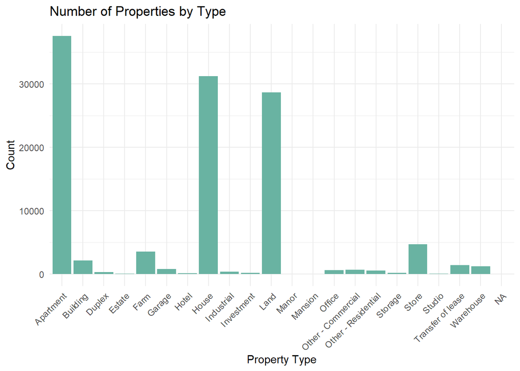

```r
ggplot(portugal_data, aes(x = Type)) +
  geom_bar(fill = "#69b3a2") +
  labs(title = "Number of Properties by Type", x = "Property Type", y = "Count") +
  theme_minimal() +
  theme(axis.text.x = element_text(angle = 45, hjust = 1))
```

We mainly have apartment, house and land.

Next we look at missing values:

```r
sapply(portugal_data, function(x) sum(is.na(x)))
```

```
##                Price             District                 City
##                  244                    0                    0
##                 Town                 Type    EnergyCertificate
##                    2                   16                    0
##                Floor                 Lift              Parking
##                86694                46408                  194
##           HasParking     ConstructionYear            TotalArea
##                46408                41073                 6452
##            GrossArea          PublishDate               Garage
##                86985                99567                68247
##             Elevator ElectricCarsCharging           TotalRooms
##                68247                68247                49355
##     NumberOfBedrooms           NumberOfWC   ConservationStatus
##                83931                73097               101542
##           LivingArea              LotSize            BuiltArea
##                27260                85694                96234
##    NumberOfBathrooms
##                 5355
```

```r
sum(is.na(portugal_data))
```

```
## [1] 1141252
```

Percentage of missing values per column

```r
sapply(portugal_data, function(x) mean(is.na(x)) * 100)
```

```
##                Price             District                 City
##          0.212871762          0.000000000          0.000000000
##                 Town                 Type    EnergyCertificate
##          0.001744851          0.013958804          0.000000000
##                Floor                 Lift              Parking
##         75.634035054         40.487511232          0.169250499
##           HasParking     ConstructionYear            TotalArea
##         40.487511232         35.833122497          5.628887745
##            GrossArea          PublishDate               Garage
##         75.887910803         86.864765361         59.540406376
##             Elevator ElectricCarsCharging           TotalRooms
##         59.540406376         59.540406376         43.058548459
##     NumberOfBedrooms           NumberOfWC   ConservationStatus
##         73.223524075         63.771668862         88.587805240
##           LivingArea              LotSize            BuiltArea
##         23.782312450         74.761609799         83.956971986
##    NumberOfBathrooms
##          4.671837240
```

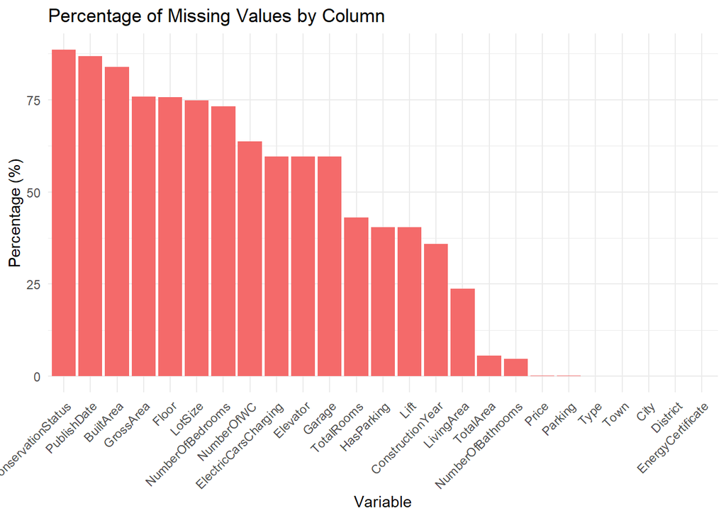

```r
missing_percentage <- sapply(portugal_data, function(x) mean(is.na(x)) * 100)

missing_df <- data.frame(
  Variable = names(missing_percentage),
  MissingPercentage = missing_percentage
)

# Plot percentage of missing values
ggplot(missing_df, aes(x = reorder(Variable, -MissingPercentage), y = MissingPercentage)) +
  geom_bar(stat = "identity", fill = "#f46a6a") +
  labs(title = "Percentage of Missing Values by Column", x = "Variable", y = "Percentage (%)") +
  theme_minimal() +
  theme(axis.text.x = element_text(angle = 45, hjust = 1))
```

If we were to remove rows with missing data, we’d end with no rows at all.

```r
portugal_data_complete_cases <- na.omit(portugal_data)
sum(is.na(portugal_data_complete_cases))  # See the missing value now
```

```
## [1] 0
```

```r
dim(portugal_data_complete_cases)    # Get the dimensions of the complete dataset (rows and columns)
```

```
## [1]  0 25
```

We visualize the missing values per variable.

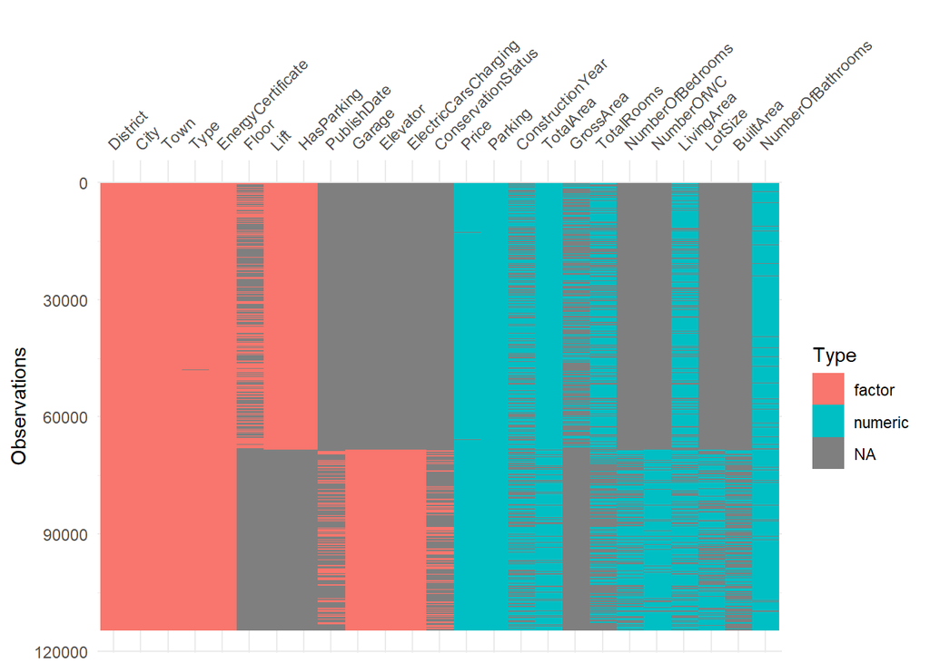

```r
visdat::vis_dat(portugal_data, warn_large_data = FALSE, large_data_size = 115000)
```

We detect that there are two columns that mean the same thing (Lift and Elevator). It seems that the rows where one column has NA, the other contains values, and vice versa. Therefore, we check which rows have matching NA values and which rows contain values in both columns.

```r
# Filter the ones that have NA in both rows
na_coincidencia <- portugal_data[is.na(portugal_data$Lift) & is.na(portugal_data$Elevator), ]

# Show the rows with NA in both columns
nrow(na_coincidencia)
```

```
## [1] 32
```

```r
# Filter rows where both columns have NA
na_coincidencia <- portugal_data[!is.na(portugal_data$Lift) & !is.na(portugal_data$Elevator), ]

# Show the rows with NA in both columns
nrow(na_coincidencia)
```

```
## [1] 0
```

Therefore, we can see that there are 32 rows where both columns contain NA values and 0 rows where both contain values. We can conclude that the two columns have the same meaning and represent the same thing. Therefore, we can combine them into a single column. When we detect values in one column, we keep that value, but when it is an NA value, we will take the value from the other column.

```r
# Create a new combined column where we prioritize the NA value
portugal_data <- portugal_data %>%
  mutate(CombinedElevator = case_when(
    !is.na(Lift) ~ as.character(Lift),
    TRUE ~ as.character(Elevator)  # Prioritize Elevator if Lift is NA
  ))

# Convert CombinedElevator to a factor
portugal_data$CombinedElevator <- as.factor(portugal_data$CombinedElevator)

# Remove the original columns if they are no longer needed
portugal_data <- portugal_data %>% select(-Lift, -Elevator)

# Check the result
head(portugal_data)
```

```
##     Price District                 City                      Town      Type
## 1  250000     Faro São Brás de Alportel      São Brás de Alportel Apartment
## 2    9500     Faro            Albufeira Albufeira e Olhos de Água Apartment
## 3  580000     Faro        Vila do Bispo                    Budens Apartment
## 4  350000     Faro             Portimão                  Portimão Apartment
## 5  175000     Faro                 Faro     Faro (Sé e São Pedro)     House
## 6 1485000     Faro                Loulé                 Quarteira     House
##   EnergyCertificate        Floor Parking HasParking ConstructionYear TotalArea
## 1                A+    2nd Floor       1       True               NA       114
## 2    No Certificate    1st Floor       0      False             1990        27
## 3                 D    3rd Floor       1       True             2003        84
## 4                 C    4th Floor       0      False             1985        68
## 5    No Certificate         <NA>       0      False             1950        78
## 6                 D Ground Floor       2       True             2004       472
##   GrossArea PublishDate Garage ElectricCarsCharging TotalRooms NumberOfBedrooms
```

[output cut: 20 more lines]

```r
# Deleted not needed HasParking column
portugal_data$HasParking <- NULL
summary(portugal_data)
```

```
##      Price              District                    City
##  Min.   :1.000e+02   Lisboa :25719   Lisboa           : 6945
##  1st Qu.:7.800e+04   Porto  :17994   Sintra           : 4502
##  Median :2.000e+05   Braga  : 9924   Vila Nova de Gaia: 3557
##  Mean   :3.666e+05   Setúbal: 9575   Porto            : 3368
##  3rd Qu.:3.900e+05   Faro   : 7717   Cascais          : 2770
##  Max.   :1.380e+09   Coimbra: 6704   Braga            : 2289
##  NA's   :244         (Other):36990   (Other)          :91192
##                                                               Town
##  Albufeira e Olhos de Água                                      :  1330
##  Cascais e Estoril                                              :  1263
##  Cedofeita, Santo Ildefonso, Sé, Miragaia, São Nicolau e Vitória:   933
##  Portimão                                                       :   901
##  Canidelo                                                       :   773
##  (Other)                                                        :109421
##  NA's                                                           :     2
##         Type            EnergyCertificate          Floor          Parking
##  Apartment:37558   No Certificate:52724   Ground Floor: 6973   Min.   :0.0000
##  House    :31171   C             :13547   1st Floor   : 6038   1st Qu.:0.0000
##  Land     :28649   D             :12913   2nd Floor   : 5019   Median :0.0000
##  Store    : 4684   E             : 9084   3rd Floor   : 3817   Mean   :0.5847
##  Farm     : 3547   A             : 8414   4th Floor   : 1902   3rd Qu.:1.0000
##  (Other)  : 8998   F             : 6429   (Other)     : 4180   Max.   :3.0000
##  NA's     :   16   (Other)       :11512   NA's        :86694   NA's   :194
##  ConstructionYear   TotalArea            GrossArea
##  Min.   :1900     Min.   :-7.196e+06   Min.   :      -7
##  1st Qu.:1972     1st Qu.: 9.500e+01   1st Qu.:     100
##  Median :1994     Median : 1.770e+02   Median :     164
##  Mean   :1989     Mean   : 6.040e+05   Mean   :    2790
##  3rd Qu.:2008     3rd Qu.: 6.210e+02   3rd Qu.:     294
##  Max.   :2024     Max.   : 6.142e+10   Max.   :12750000
##  NA's   :41073    NA's   :6452         NA's   :86985
##                   PublishDate      Garage      ElectricCarsCharging
##  2024-05-14 06:54:48.730:    3   False:38558   False:42052
##  2024-07-29 10:00:47.103:    3   True : 7818   True : 4324
##  2024-08-08 15:00:26.257:    3   NA's :68247   NA's :68247
##  2018-10-31 22:08:50.903:    2
##  2021-05-06 14:18:52.147:    2
##  (Other)                :15043
##  NA's                   :99567
```

[output cut: 9 more lines]

```
##  Min.   :      0   Min.   :        0   Min.   :      -1   Min.   :-13.000
##  1st Qu.:     80   1st Qu.:      296   1st Qu.:     107   1st Qu.:  0.000
##  Median :    121   Median :      795   Median :     178   Median :  1.000
##  Mean   :   1542   Mean   :    73454   Mean   :    3682   Mean   :  1.503
##  3rd Qu.:    215   3rd Qu.:     3300   3rd Qu.:     322   3rd Qu.:  2.000
##  Max.   :5429000   Max.   :992301000   Max.   :12750000   Max.   : 90.000
##  NA's   :27260     NA's   :85694       NA's   :96234      NA's   :5355
##  CombinedElevator
##  False:86923
##  True :27668
##  NA's :   32
##
##
##
##
```

We’ll separate into the 3 biggest type of real estate, it will help us treating missing values and outliers, since values can differ a lot between a House and a Land.

```r
dataset_apartment <- subset(portugal_data, Type == "Apartment")
dataset_land <- subset(portugal_data, Type == "Land")
dataset_house <- subset(portugal_data, Type == "House")
```

We visualize the missing values by percentage for each of the types.

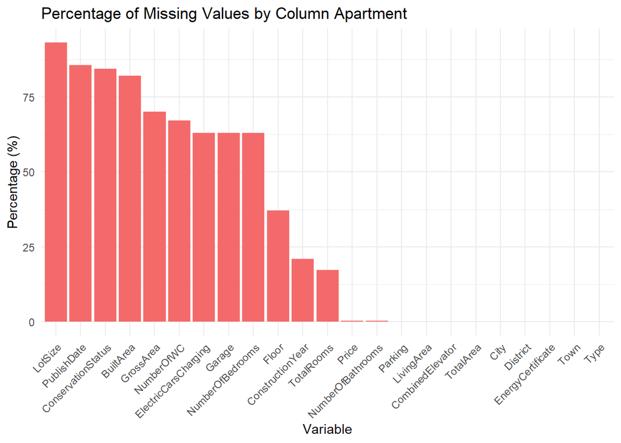

```r
missing_percentage <- sapply(dataset_apartment, function(x) mean(is.na(x)) * 100)

missing_df <- data.frame(
  Variable = names(missing_percentage),
  MissingPercentage = missing_percentage
)

# Plot percentage of missing values
ggplot(missing_df, aes(x = reorder(Variable, -MissingPercentage), y = MissingPercentage)) +
  geom_bar(stat = "identity", fill = "#f46a6a") +
  labs(title = "Percentage of Missing Values by Column Apartment", x = "Variable", y = "Percentage (%)") +
  theme_minimal() +
  theme(axis.text.x = element_text(angle = 45, hjust = 1))
```

[figure not shown]

```r
missing_percentage <- sapply(dataset_apartment, function(x) mean(is.na(x)) * 100)

missing_df <- data.frame(
  Variable = names(missing_percentage),
  MissingPercentage = missing_percentage
)

# Plot percentage of missing values
ggplot(missing_df, aes(x = reorder(Variable, -MissingPercentage), y = MissingPercentage)) +
  geom_bar(stat = "identity", fill = "#f46a6a") +
  labs(title = "Percentage of Missing Values by Column Land", x = "Variable", y = "Percentage (%)") +
  theme_minimal() +
  theme(axis.text.x = element_text(angle = 45, hjust = 1))
```

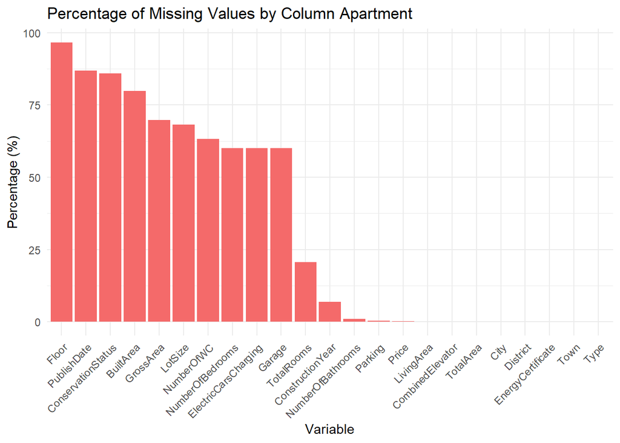

```r
missing_percentage <- sapply(dataset_house, function(x) mean(is.na(x)) * 100)

missing_df <- data.frame(
  Variable = names(missing_percentage),
  MissingPercentage = missing_percentage
)

# Plot percentage of missing values
ggplot(missing_df, aes(x = reorder(Variable, -MissingPercentage), y = MissingPercentage)) +
  geom_bar(stat = "identity", fill = "#f46a6a") +
  labs(title = "Percentage of Missing Values by Column Apartment", x = "Variable", y = "Percentage (%)") +
  theme_minimal() +
  theme(axis.text.x = element_text(angle = 45, hjust = 1))
```

We can see how the most common columns with missing values differ between types, meaning it’s a good decision to split the dataset in 3 different ones.

For better visualization we’ll show these percentages for all 3 types in the same table.

```r
# Calculate missing percentages for all three datasets
missing_percentages <- data.frame(
  Variable = names(dataset_apartment),
  Apartment = sapply(dataset_apartment, function(x) mean(is.na(x)) * 100),
  Land = sapply(dataset_land, function(x) mean(is.na(x)) * 100),
  House = sapply(dataset_house, function(x) mean(is.na(x)) * 100)
)

# Print the summary table
print(missing_percentages)
```

```
##                                  Variable    Apartment         Land       House
## Price                               Price  0.340806220  0.073300988  0.15398928
## District                         District  0.000000000  0.000000000  0.00000000
## City                                 City  0.000000000  0.000000000  0.00000000
## Town                                 Town  0.000000000  0.006981046  0.00000000
## Type                                 Type  0.000000000  0.000000000  0.00000000
## EnergyCertificate       EnergyCertificate  0.000000000  0.000000000  0.00000000
## Floor                               Floor 37.123915011 99.832454885 96.57694652
## Parking                           Parking  0.050588423  0.094244127  0.38176510
## ConstructionYear         ConstructionYear 20.980882901 85.521309644  6.81081775
## TotalArea                       TotalArea  0.007987646 22.398687563  0.01924866
## GrossArea                       GrossArea 70.019702860 88.373067123 69.76997851
## PublishDate                   PublishDate 85.619575057 88.585989040 86.78579449
## Garage                             Garage 62.942648703 55.548186673 60.04619679
## ElectricCarsCharging ElectricCarsCharging 62.942648703 55.548186673 60.04619679
## TotalRooms                     TotalRooms 17.314553491 86.599881322 20.54473710
## NumberOfBedrooms         NumberOfBedrooms 62.942648703 92.882823135 60.05261301
## NumberOfWC                     NumberOfWC 67.101549603 61.045760760 63.14202303
## ConservationStatus     ConservationStatus 84.485329357 97.682292576 85.95489397
## LivingArea                     LivingArea  0.010650194 71.105448707  0.03208110
## LotSize                           LotSize 93.194525800 55.579601382 68.15950723
## BuiltArea                       BuiltArea 82.067735236 90.446437921 79.87552533
## NumberOfBathrooms       NumberOfBathrooms  0.287555248 12.387866941  0.92393571
## CombinedElevator         CombinedElevator  0.007987646  0.031414709  0.01924866
```

```r
# Highlight columns that are completely empty in one dataset but not others
missing_percentages$CompletelyEmpty <- with(missing_percentages,
  ifelse(Apartment == 100 & Land < 100 & House < 100, "Apartment",
  ifelse(Land == 100 & Apartment < 100 & House < 100, "Land",
  ifelse(House == 100 & Apartment < 100 & Land < 100, "House", NA)))
)

print(missing_percentages)
```

```
##                                  Variable    Apartment         Land       House
## Price                               Price  0.340806220  0.073300988  0.15398928
## District                         District  0.000000000  0.000000000  0.00000000
## City                                 City  0.000000000  0.000000000  0.00000000
## Town                                 Town  0.000000000  0.006981046  0.00000000
## Type                                 Type  0.000000000  0.000000000  0.00000000
## EnergyCertificate       EnergyCertificate  0.000000000  0.000000000  0.00000000
## Floor                               Floor 37.123915011 99.832454885 96.57694652
## Parking                           Parking  0.050588423  0.094244127  0.38176510
## ConstructionYear         ConstructionYear 20.980882901 85.521309644  6.81081775
## TotalArea                       TotalArea  0.007987646 22.398687563  0.01924866
## GrossArea                       GrossArea 70.019702860 88.373067123 69.76997851
## PublishDate                   PublishDate 85.619575057 88.585989040 86.78579449
## Garage                             Garage 62.942648703 55.548186673 60.04619679
## ElectricCarsCharging ElectricCarsCharging 62.942648703 55.548186673 60.04619679
## TotalRooms                     TotalRooms 17.314553491 86.599881322 20.54473710
## NumberOfBedrooms         NumberOfBedrooms 62.942648703 92.882823135 60.05261301
## NumberOfWC                     NumberOfWC 67.101549603 61.045760760 63.14202303
## ConservationStatus     ConservationStatus 84.485329357 97.682292576 85.95489397
## LivingArea                     LivingArea  0.010650194 71.105448707  0.03208110
## LotSize                           LotSize 93.194525800 55.579601382 68.15950723
## BuiltArea                       BuiltArea 82.067735236 90.446437921 79.87552533
## NumberOfBathrooms       NumberOfBathrooms  0.287555248 12.387866941  0.92393571
## CombinedElevator         CombinedElevator  0.007987646  0.031414709  0.01924866
##                      CompletelyEmpty
## Price                             NA
## District                          NA
## City                              NA
## Town                              NA
## Type                              NA
## EnergyCertificate                 NA
## Floor                             NA
## Parking                           NA
## ConstructionYear                  NA
## TotalArea                         NA
## GrossArea                         NA
## PublishDate                       NA
## Garage                            NA
## ElectricCarsCharging              NA
## TotalRooms                        NA
## NumberOfBedrooms                  NA
## NumberOfWC                        NA
## ConservationStatus                NA
## LivingArea                        NA
## LotSize                           NA
## BuiltArea                         NA
## NumberOfBathrooms                 NA
## CombinedElevator                  NA
```

We can see that there are variables in certain datasets that no longer have as many NAs. For example, Floor for apartments, ConstructionYear for both apartments and houses, among others. However, LivingArea still has 71% NAs in the land dataset.

Next we’ll see a graph with the missing value columns of all 3 types in the same graph.

```r
# Calculate missing percentages for all three datasets
missing_percentages <- data.frame(
  Variable = names(dataset_apartment),
  Apartment = sapply(dataset_apartment, function(x) mean(is.na(x)) * 100),
  Land = sapply(dataset_land, function(x) mean(is.na(x)) * 100),
  House = sapply(dataset_house, function(x) mean(is.na(x)) * 100)
)

# Identify columns with more than 50% missing values in any dataset
missing_percentages$ToBeDropped <- with(missing_percentages,
  ifelse(Apartment > 50 | Land > 50 | House > 50, "Yes", "No")
)

# Print the summary table with missing percentages and columns to be dropped
print(missing_percentages)
```

```
##                                  Variable    Apartment         Land       House
## Price                               Price  0.340806220  0.073300988  0.15398928
## District                         District  0.000000000  0.000000000  0.00000000
## City                                 City  0.000000000  0.000000000  0.00000000
## Town                                 Town  0.000000000  0.006981046  0.00000000
## Type                                 Type  0.000000000  0.000000000  0.00000000
## EnergyCertificate       EnergyCertificate  0.000000000  0.000000000  0.00000000
## Floor                               Floor 37.123915011 99.832454885 96.57694652
## Parking                           Parking  0.050588423  0.094244127  0.38176510
## ConstructionYear         ConstructionYear 20.980882901 85.521309644  6.81081775
## TotalArea                       TotalArea  0.007987646 22.398687563  0.01924866
## GrossArea                       GrossArea 70.019702860 88.373067123 69.76997851
## PublishDate                   PublishDate 85.619575057 88.585989040 86.78579449
## Garage                             Garage 62.942648703 55.548186673 60.04619679
## ElectricCarsCharging ElectricCarsCharging 62.942648703 55.548186673 60.04619679
## TotalRooms                     TotalRooms 17.314553491 86.599881322 20.54473710
## NumberOfBedrooms         NumberOfBedrooms 62.942648703 92.882823135 60.05261301
## NumberOfWC                     NumberOfWC 67.101549603 61.045760760 63.14202303
## ConservationStatus     ConservationStatus 84.485329357 97.682292576 85.95489397
## LivingArea                     LivingArea  0.010650194 71.105448707  0.03208110
## LotSize                           LotSize 93.194525800 55.579601382 68.15950723
## BuiltArea                       BuiltArea 82.067735236 90.446437921 79.87552533
## NumberOfBathrooms       NumberOfBathrooms  0.287555248 12.387866941  0.92393571
## CombinedElevator         CombinedElevator  0.007987646  0.031414709  0.01924866
##                      ToBeDropped
## Price                         No
## District                      No
## City                          No
## Town                          No
## Type                          No
## EnergyCertificate             No
## Floor                        Yes
## Parking                       No
## ConstructionYear             Yes
## TotalArea                     No
## GrossArea                    Yes
## PublishDate                  Yes
## Garage                       Yes
## ElectricCarsCharging         Yes
## TotalRooms                   Yes
## NumberOfBedrooms             Yes
## NumberOfWC                   Yes
## ConservationStatus           Yes
## LivingArea                   Yes
## LotSize                      Yes
## BuiltArea                    Yes
## NumberOfBathrooms             No
## CombinedElevator              No
```

```r
# Filter only the columns that will be dropped
columns_to_drop <- missing_percentages[missing_percentages$ToBeDropped == "Yes", ]
print("Columns with more than 50% missing values (to be dropped):")
```

```
## [1] "Columns with more than 50% missing values (to be dropped):"
```

```r
print(columns_to_drop)
```

```
##                                  Variable   Apartment     Land      House
## Floor                               Floor 37.12391501 99.83245 96.5769465
## ConstructionYear         ConstructionYear 20.98088290 85.52131  6.8108177
## GrossArea                       GrossArea 70.01970286 88.37307 69.7699785
## PublishDate                   PublishDate 85.61957506 88.58599 86.7857945
## Garage                             Garage 62.94264870 55.54819 60.0461968
## ElectricCarsCharging ElectricCarsCharging 62.94264870 55.54819 60.0461968
## TotalRooms                     TotalRooms 17.31455349 86.59988 20.5447371
## NumberOfBedrooms         NumberOfBedrooms 62.94264870 92.88282 60.0526130
## NumberOfWC                     NumberOfWC 67.10154960 61.04576 63.1420230
## ConservationStatus     ConservationStatus 84.48532936 97.68229 85.9548940
## LivingArea                     LivingArea  0.01065019 71.10545  0.0320811
## LotSize                           LotSize 93.19452580 55.57960 68.1595072
## BuiltArea                       BuiltArea 82.06773524 90.44644 79.8755253
##                      ToBeDropped
## Floor                        Yes
## ConstructionYear             Yes
## GrossArea                    Yes
## PublishDate                  Yes
## Garage                       Yes
## ElectricCarsCharging         Yes
## TotalRooms                   Yes
## NumberOfBedrooms             Yes
## NumberOfWC                   Yes
## ConservationStatus           Yes
## LivingArea                   Yes
## LotSize                      Yes
## BuiltArea                    Yes
```

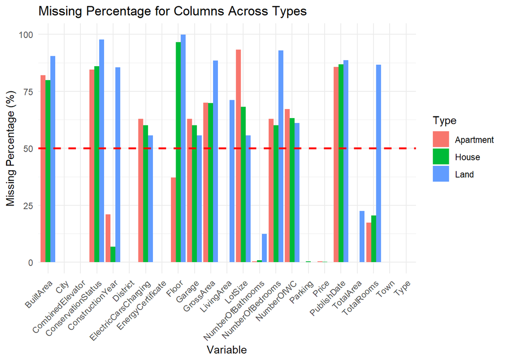

```r
# Optionally, visualize the columns with more than 50% missing values
missing_percentages_long <- tidyr::pivot_longer(
  missing_percentages,
  cols = c(Apartment, Land, House),
  names_to = "Dataset",
  values_to = "MissingPercentage"
)

# Plot the missing percentages for all datasets
ggplot(missing_percentages_long, aes(x = Variable, y = MissingPercentage, fill = Dataset)) +
  geom_bar(stat = "identity", position = "dodge") +
  geom_hline(yintercept = 50, linetype = "dashed", color = "red", size = 1) +
  labs(
    title = "Missing Percentage for Columns Across Types",
    x = "Variable",
    y = "Missing Percentage (%)",
    fill = "Type"
  ) +
  theme_minimal() +
  theme(axis.text.x = element_text(angle = 45, hjust = 1))
```

Another view on the missing values.

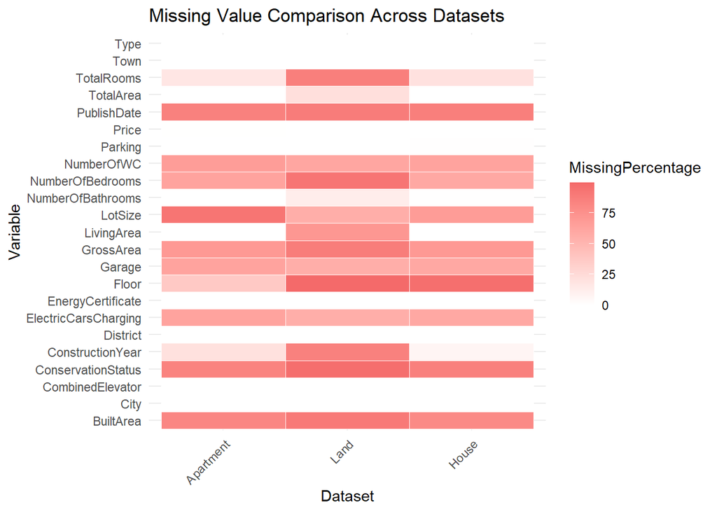

```r
# Reshape the data for plotting
missing_melt <- melt(missing_percentages, id.vars = "Variable",
                     measure.vars = c("Apartment", "Land", "House"),
                     variable.name = "Dataset", value.name = "MissingPercentage")

# Plot the heatmap
ggplot(missing_melt, aes(x = Dataset, y = Variable, fill = MissingPercentage)) +
  geom_tile(color = "white") +
  scale_fill_gradient(low = "white", high = "#f46a6a", na.value = "white") +
  labs(title = "Missing Value Comparison Across Datasets", x = "Dataset", y = "Variable") +
  theme_minimal() +
  theme(axis.text.x = element_text(angle = 45, hjust = 1))
```

We’ll remove the columns with a higher percentage than 50 in the clean_dataset method.

```r
handle_outliers_by_type <- function(df, columns) {
  # Remove rows with outliers for the given columns
  df <- df %>%
    filter(
      # Retain rows within the bounds for all specified columns
      rowSums(sapply(df[columns], function(.x) {
        Q1 <- quantile(.x, 0.25, na.rm = TRUE)
        Q3 <- quantile(.x, 0.75, na.rm = TRUE)
        IQR <- Q3 - Q1
        lower_bound <- pmax(0, Q1 - 1.5 * IQR)
        upper_bound <- Q3 + 1.5 * IQR
        # Return TRUE if the value is within the bounds
        !(.x < lower_bound | .x > upper_bound)
      })) == length(columns)
    )

  return(df)
}

clean_dataset <- function(data) {
  # Handle missing values
  missing_percentage <- colSums(is.na(data)) / nrow(data) * 100
  columns_to_drop <- names(missing_percentage[missing_percentage > 50])
  data <- data[, setdiff(names(data), columns_to_drop)]

  # Impute missing numeric values with median
  numeric_cols <- sapply(data, is.numeric)
  data[, numeric_cols] <- lapply(data[, numeric_cols], function(x) {
    ifelse(is.na(x), median(x, na.rm = TRUE), x)
  })

  # Impute missing categorical values with the most frequent value
  categorical_cols <- sapply(data, is.factor)
  data[, categorical_cols] <- lapply(data[, categorical_cols], function(x) {
    x[is.na(x)] <- names(sort(table(x), decreasing = TRUE))[1]
    return(as.factor(x))
  })

  # Handle outliers for numeric columns
  columns_to_fix <- names(data)[sapply(data, is.numeric)]
  data <- handle_outliers_by_type(data, columns_to_fix)

  return(data)
}
```

```r
dataset_apartment_test <- clean_dataset(dataset_apartment)

summary(dataset_apartment_test)
```

```
##      Price           District                   City
##  Min.   :   875   Lisboa :8721   Lisboa           : 2348
##  1st Qu.:185000   Porto  :5664   Sintra           : 1672
##  Median :252500   Setúbal:3371   Porto            : 1598
##  Mean   :290775   Faro   :2653   Vila Nova de Gaia: 1556
##  3rd Qu.:365000   Braga  :1960   Braga            :  820
##  Max.   :785000   Aveiro :1250   Oeiras           :  761
##                   (Other):4261   (Other)          :19125
##                                                               Town
##  Albufeira e Olhos de Água                                      :  534
##  Canidelo                                                       :  444
##  Cedofeita, Santo Ildefonso, Sé, Miragaia, São Nicolau e Vitória:  416
##  Portimão                                                       :  383
##  Quarteira                                                      :  372
##  São Sebastião                                                  :  345
##  (Other)                                                        :25386
##         Type            EnergyCertificate          Floor          Parking
##  Apartment:27880   C             :5671    1st Floor   :14769   Min.   :0.0000
##  Building :    0   No Certificate:5529    2nd Floor   : 3612   1st Qu.:0.0000
##  Duplex   :    0   D             :5404    Ground Floor: 2994   Median :1.0000
##  Estate   :    0   A             :4016    3rd Floor   : 2799   Mean   :0.6327
##  Farm     :    0   E             :2640    4th Floor   : 1311   3rd Qu.:1.0000
##  Garage   :    0   A+            :1467    5th Floor   :  770   Max.   :2.0000
##  (Other)  :    0   (Other)       :3153    (Other)     : 1625
##  ConstructionYear   TotalArea        TotalRooms      LivingArea
##  Min.   :1959     Min.   :  0.00   Min.   :1.000   Min.   :  0.00
##  1st Qu.:1990     1st Qu.: 74.00   1st Qu.:2.000   1st Qu.: 70.00
##  Median :1999     Median : 96.00   Median :3.000   Median : 90.00
##  Mean   :2000     Mean   : 99.29   Mean   :2.543   Mean   : 92.17
##  3rd Qu.:2008     3rd Qu.:122.00   3rd Qu.:3.000   3rd Qu.:111.00
##  Max.   :2024     Max.   :235.00   Max.   :4.000   Max.   :200.00
##
##  NumberOfBathrooms CombinedElevator
##  Min.   :0.000     False: 9027
##  1st Qu.:1.000     True :18853
##  Median :2.000
##  Mean   :1.658
##  3rd Qu.:2.000
##  Max.   :3.000
##
```

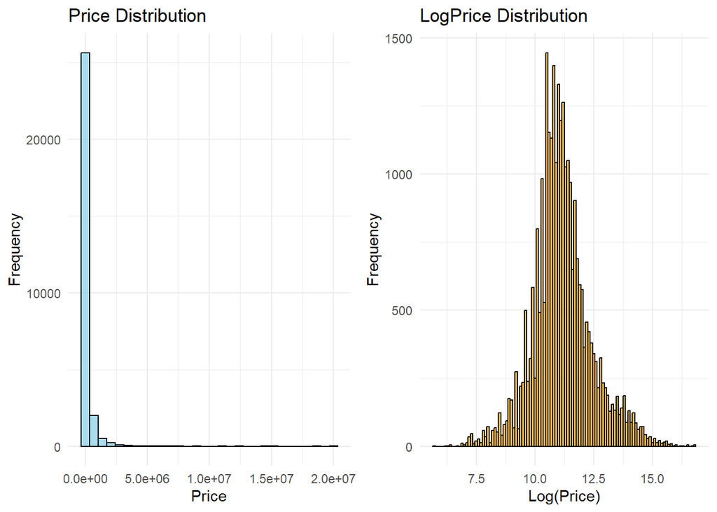

```r
# Create the histograms
p1 <- ggplot(dataset_land, aes(x = Price)) +
  geom_histogram(fill = "skyblue", color = "black", alpha = 0.7) +
  labs(title = "Price Distribution", x = "Price", y = "Frequency") +
  theme_minimal()

p2 <- ggplot(dataset_land, aes(x = log(Price))) +
  geom_histogram(binwidth = 0.1, fill = "orange", color = "black", alpha = 0.7) +
  labs(title = "LogPrice Distribution", x = "Log(Price)", y = "Frequency") +
  theme_minimal()

# Use gridExtra to display them side by side
library(gridExtra)
grid.arrange(p1, p2, ncol = 2)
```

After applying the transformation we can see how it’s normalized now. We’ll check the distribution of all other variables.

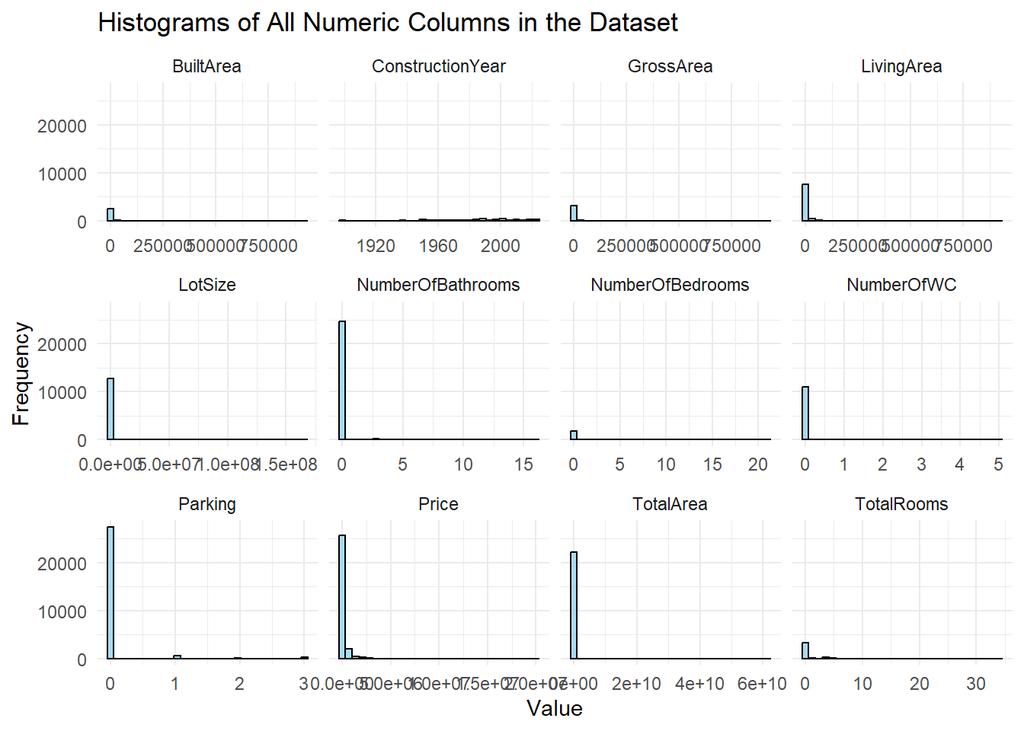

```r
library(ggplot2)
library(tidyr)
library(dplyr)

plot_histograms_for_all_columns <- function(data) {
  # Select only numeric columns
  numeric_data <- data %>%
    select(where(is.numeric))

  # Convert dataset to long format using pivot_longer
  data_long <- numeric_data %>%
    pivot_longer(cols = everything(), names_to = "Variable", values_to = "Value")

  # Plot histograms for all numeric columns
  ggplot(data_long, aes(x = Value)) +
    geom_histogram(bins = 30, fill = "skyblue", color = "black", alpha = 0.7) +
    facet_wrap(~ Variable, scales = "free_x", ncol = 4) +
    theme_minimal() +
    labs(
      title = "Histograms of All Numeric Columns in the Dataset",
      x = "Value",
      y = "Frequency"
    )
}

# Example: Plot histograms for the dataset_land
plot_histograms_for_all_columns(dataset_land)
```

Not a single normalized one, so we’ll modify the method to transform the variables to log before aplying IQR.

```r
handle_outliers_with_log <- function(df, columns) {
  # Detect and handle outliers after transformation
  df <- df %>%
    filter(
      rowSums(sapply(df[columns], function(.x) {
        Q1 <- quantile(.x, 0.25, na.rm = TRUE)
        Q3 <- quantile(.x, 0.75, na.rm = TRUE)
        IQR <- Q3 - Q1
        lower_bound <- Q1 - 1.5 * IQR
        upper_bound <- Q3 + 1.5 * IQR
        !(.x < lower_bound | .x > upper_bound)
      })) == length(columns)
    )
  return(df)
}

clean_dataset_with_log <- function(data) {
  # Handle missing values: Drop columns with >50% missing data
  missing_percentage <- colSums(is.na(data)) / nrow(data) * 100
  columns_to_drop <- names(missing_percentage[missing_percentage > 50])
  data <- data[, setdiff(names(data), columns_to_drop)]

  # Identify numeric and categorical columns
  numeric_columns <- names(data)[sapply(data, is.numeric)]
  categorical_columns <- names(data)[sapply(data, is.factor)]

  # Impute missing numeric values with median
  data[, numeric_columns] <- lapply(data[, numeric_columns], function(x) {
    ifelse(is.na(x), median(x, na.rm = TRUE), x)
  })

  # Impute missing categorical values with the most frequent value
  data[, categorical_columns] <- lapply(data[, categorical_columns], function(x) {
    x[is.na(x)] <- names(sort(table(x), decreasing = TRUE))[1]
    return(as.factor(x))
  })

  # Drop rows with negative values in numeric columns
  data <- data %>%
    filter(
      # Keep rows where all numeric columns have non-negative values
      !rowSums(data[, numeric_columns] < 0, na.rm = TRUE) > 0
    )

  # Add log-transformed column for Price
  data <- data %>%
    mutate(across(all_of(numeric_columns), ~ log(.x + 1), .names = "Log_{.col}"))

  numeric_columns <- names(data)[sapply(data, is.numeric)]

  # Handle outliers for numeric columns (including LogPriceXd)
  data <- handle_outliers_with_log(data, numeric_columns)

  log_columns <- paste("Log", numeric_columns, sep = "_")  # Create column names for log-transformed columns
  data <- data[, !names(data) %in% log_columns]  # Remove log-transformed columns

  return(data)
}
```

```r
dataset_apartment_cleaned <- clean_dataset_with_log(dataset_apartment)
dataset_land_cleaned <- clean_dataset_with_log(dataset_land)
dataset_house_cleaned <- clean_dataset_with_log(dataset_house)

summary(dataset_apartment_cleaned)
```

```
##      Price           District                   City
##  Min.   : 57500   Lisboa :8282   Lisboa           : 2152
##  1st Qu.:189000   Porto  :5487   Sintra           : 1629
##  Median :259000   Setúbal:3171   Vila Nova de Gaia: 1526
##  Mean   :296814   Faro   :2147   Porto            : 1524
##  3rd Qu.:370000   Braga  :1686   Oeiras           :  733
##  Max.   :780000   Aveiro :1183   Loures           :  711
##                   (Other):3957   (Other)          :17638
##                                                               Town
##  Canidelo                                                       :  443
##  Cedofeita, Santo Ildefonso, Sé, Miragaia, São Nicolau e Vitória:  390
##  Portimão                                                       :  377
##  São Sebastião                                                  :  338
##  Santo António dos Cavaleiros e Frielas                         :  320
##  Montijo e Afonsoeiro                                           :  315
##  (Other)                                                        :23730
##         Type            EnergyCertificate          Floor          Parking
##  Apartment:25913   C             :5432    1st Floor   :13633   Min.   :0.0000
##  Building :    0   D             :5147    2nd Floor   : 3403   1st Qu.:0.0000
##  Duplex   :    0   No Certificate:4794    Ground Floor: 2794   Median :1.0000
##  Estate   :    0   A             :3758    3rd Floor   : 2640   Mean   :0.6369
##  Farm     :    0   E             :2509    4th Floor   : 1215   3rd Qu.:1.0000
##  Garage   :    0   A+            :1373    5th Floor   :  718   Max.   :2.0000
##  (Other)  :    0   (Other)       :2900    (Other)     : 1510
##  ConstructionYear   TotalArea       TotalRooms      LivingArea
##  Min.   :1960     Min.   : 30.0   Min.   :1.000   Min.   : 31.00
##  1st Qu.:1990     1st Qu.: 76.0   1st Qu.:2.000   1st Qu.: 71.00
##  Median :1999     Median : 97.0   Median :3.000   Median : 91.00
##  Mean   :2000     Mean   :101.5   Mean   :2.562   Mean   : 93.48
##  3rd Qu.:2008     3rd Qu.:123.0   3rd Qu.:3.000   3rd Qu.:112.00
##  Max.   :2024     Max.   :235.0   Max.   :4.000   Max.   :200.00
##
##  NumberOfBathrooms CombinedElevator
##  Min.   :1.000     False: 8440
##  1st Qu.:1.000     True :17473
##  Median :2.000
##  Mean   :1.731
##  3rd Qu.:2.000
##  Max.   :3.000
##
```

```r
summary(dataset_land_cleaned)
```

```
##      Price            District                   City
##  Min.   :  4900   Porto   :3194   Sintra           :  625
##  1st Qu.: 32500   Lisboa  :2300   Coimbra          :  456
##  Median : 55000   Braga   :2127   Vila Nova de Gaia:  421
##  Mean   : 70482   Aveiro  :1988   Felgueiras       :  375
##  3rd Qu.: 90000   Santarém:1848   Vila Verde       :  356
##  Max.   :272500   Leiria  :1804   Figueira da Foz  :  347
##                   (Other) :7364   (Other)          :18045
##                              Town              Type
##  São João das Lampas e Terrugem:  239   Land     :20625
##  Pombal                        :  143   Apartment:    0
##  Palmela                       :  120   Building :    0
##  Castelo (Sesimbra)            :  116   Duplex   :    0
##  Charneca de Caparica e Sobreda:  113   Estate   :    0
##  Quinta do Anjo                :  113   Farm     :    0
##  (Other)                       :19781   (Other)  :    0
##       EnergyCertificate    Parking    TotalArea    NumberOfBathrooms
##  No Certificate:20526   Min.   :0   Min.   :  56   Min.   :0
##  A+            :   27   1st Qu.:0   1st Qu.: 600   1st Qu.:0
##  G             :   26   Median :0   Median :1600   Median :0
##  A             :   20   Mean   :0   Mean   :1863   Mean   :0
##  B             :   11   3rd Qu.:0   3rd Qu.:2000   3rd Qu.:0
##  E             :    6   Max.   :0   Max.   :8400   Max.   :0
##  (Other)       :    9
##  CombinedElevator
##  False:20597
##  True :   28
##
##
##
##
##
```

```r
summary(dataset_house_cleaned)
```

```
##      Price            District                   City
##  Min.   :   9900   Lisboa :3019   Sintra           :  580
##  1st Qu.:  95000   Braga  :2694   Braga            :  514
##  Median : 234900   Porto  :2641   Guimarães        :  450
##  Mean   : 282568   Setúbal:1684   Vila Nova de Gaia:  434
##  3rd Qu.: 399000   Leiria :1486   Torres Vedras    :  385
##  Max.   :1015000   Coimbra:1469   Cascais          :  359
##                    (Other):8023   (Other)          :18294
##                                                                         Town
##  Charneca de Caparica e Sobreda                                           :  174
##  Fernão Ferro                                                             :  167
##  São Domingos de Rana                                                     :  164
##  Azeitão (São Lourenço e São Simão)                                       :  159
##  Palmela                                                                  :  145
##  Sintra (Santa Maria e São Miguel, São Martinho e São Pedro de Penaferrim):  126
##  (Other)                                                                  :20081
##         Type            EnergyCertificate    Parking       ConstructionYear
##  House    :21016   No Certificate:6390    Min.   :0.0000   Min.   :1900
##  Apartment:    0   E             :3163    1st Qu.:0.0000   1st Qu.:1953
##  Building :    0   F             :3003    Median :1.0000   Median :1986
##  Duplex   :    0   D             :2800    Mean   :0.8854   Mean   :1982
##  Estate   :    0   C             :1802    3rd Qu.:1.0000   3rd Qu.:2005
##  Farm     :    0   A             :1369    Max.   :3.0000   Max.   :2024
##  (Other)  :    0   (Other)       :2489
##    TotalArea       TotalRooms      LivingArea    NumberOfBathrooms
##  Min.   : 20.0   Min.   :2.000   Min.   : 25.0   Min.   :0.000
##  1st Qu.:108.0   1st Qu.:3.000   1st Qu.: 91.0   1st Qu.:1.000
##  Median :184.0   Median :3.000   Median :143.0   Median :2.000
##  Mean   :240.5   Mean   :3.253   Mean   :156.8   Mean   :2.113
##  3rd Qu.:305.0   3rd Qu.:4.000   3rd Qu.:205.0   3rd Qu.:3.000
##  Max.   :975.0   Max.   :5.000   Max.   :449.0   Max.   :6.000
##
##  CombinedElevator
##  False:20890
##  True :  126
##
##
##
##
##
```

This gave a much better result in the ones we had problems.

# 3. Main Question

**What characteristics should be prioritized to invest in houses in Portugal?**

We divide the problem into 3 different but related sub questions, in order to structure better the problem.

## First Subquestion

**Which internal factors have the greatest potential for revaluation? What impact do additional services (parking, lift…) have on the investment decision?**

```r
# Assign factor levels to the EnergyCertificate column for apartments
dataset_apartment_cleaned$EnergyCertificate <- factor(
  dataset_apartment_cleaned$EnergyCertificate,
  levels = c("No Certificate", "G", "F", "E", "D", "C", "B-", "B", "A", "A+")
)

# Assign factor levels to the EnergyCertificate column for houses
dataset_house_cleaned$EnergyCertificate <- factor(
  dataset_house_cleaned$EnergyCertificate,
  levels = c("No Certificate", "G", "F", "E", "D", "C", "B-", "B", "A", "A+")
)

# Assign factor levels to the EnergyCertificate column for land
dataset_land_cleaned$EnergyCertificate <- factor(
  dataset_land_cleaned$EnergyCertificate,
  levels = c("No Certificate", "G", "F", "E", "D", "C", "B-", "B", "A", "A+")
)

# Convert factors to numeric values for apartments
processed_data <- dataset_apartment_cleaned %>%
  mutate(across(where(is.factor), ~ as.numeric(as.factor(.))))  # Convert factors to numeric values

# Select numeric columns
all_numeric_vars <- processed_data %>%
  select(where(is.numeric))

# Remove constant columns (zero variance)
all_numeric_vars <- all_numeric_vars %>%
  select(where(~ var(., na.rm = TRUE) > 0))

# Calculate the correlation matrix (handling missing values)
correlation_matrix <- cor(all_numeric_vars, use = "pairwise.complete.obs")

correlation_matrix
```

```
##                          Price     District         City         Town
## Price              1.000000000  0.090009498  0.002337429 -0.069339730
## District           0.090009498  1.000000000  0.260381949 -0.033091037
## City               0.002337429  0.260381949  1.000000000  0.229117566
## Town              -0.069339730 -0.033091037  0.229117566  1.000000000
## EnergyCertificate  0.145016041 -0.006838086 -0.013999803  0.046756267
## Floor             -0.056715540  0.001404174 -0.008374267 -0.003052283
## Parking            0.327822999 -0.081052168  0.072827861  0.045028608
## ConstructionYear   0.294046642 -0.121150963  0.037481530  0.079565742
## TotalArea          0.310138527 -0.073422632  0.003426833  0.072716809
## TotalRooms         0.150885035 -0.008545226 -0.022385331  0.051582154
## LivingArea         0.285710862 -0.085104535  0.027948516  0.091685630
## NumberOfBathrooms  0.404258509 -0.080356134  0.037327626  0.057115763
## CombinedElevator   0.356260445 -0.050763236  0.096991028  0.023973904
##                   EnergyCertificate        Floor      Parking ConstructionYear
## Price                   0.145016041 -0.056715540  0.327822999       0.29404664
## District               -0.006838086  0.001404174 -0.081052168      -0.12115096
## City                   -0.013999803 -0.008374267  0.072827861       0.03748153
## Town                    0.046756267 -0.003052283  0.045028608       0.07956574
## EnergyCertificate       1.000000000 -0.016793191  0.097715180       0.15311850
## Floor                  -0.016793191  1.000000000  0.065228740      -0.08210513
## Parking                 0.097715180  0.065228740  1.000000000       0.35288612
## ConstructionYear        0.153118500 -0.082105135  0.352886118       1.00000000
## TotalArea               0.113495679 -0.012284349  0.309652522       0.19724744
## TotalRooms              0.028781018 -0.275446453  0.004928706       0.02952411
## LivingArea              0.079640296 -0.046635514  0.340746961       0.22664123
## NumberOfBathrooms       0.131170801 -0.044026300  0.374951654       0.25328772
## CombinedElevator        0.129234682 -0.046131488  0.351456171       0.35278998
##                      TotalArea   TotalRooms  LivingArea NumberOfBathrooms
## Price              0.310138527  0.150885035  0.28571086        0.40425851
## District          -0.073422632 -0.008545226 -0.08510454       -0.08035613
## City               0.003426833 -0.022385331  0.02794852        0.03732763
## Town               0.072716809  0.051582154  0.09168563        0.05711576
## EnergyCertificate  0.113495679  0.028781018  0.07964030        0.13117080
## Floor             -0.012284349 -0.275446453 -0.04663551       -0.04402630
## Parking            0.309652522  0.004928706  0.34074696        0.37495165
## ConstructionYear   0.197247439  0.029524110  0.22664123        0.25328772
## TotalArea          1.000000000  0.445073327  0.80512459        0.58487845
## TotalRooms         0.445073327  1.000000000  0.50670602        0.42846471
## LivingArea         0.805124589  0.506706015  1.00000000        0.62994126
## NumberOfBathrooms  0.584878448  0.428464709  0.62994126        1.00000000
## CombinedElevator   0.164077102  0.003862902  0.18377742        0.26878432
##                   CombinedElevator
## Price                  0.356260445
## District              -0.050763236
## City                   0.096991028
## Town                   0.023973904
## EnergyCertificate      0.129234682
## Floor                 -0.046131488
## Parking                0.351456171
## ConstructionYear       0.352789980
## TotalArea              0.164077102
## TotalRooms             0.003862902
## LivingArea             0.183777419
## NumberOfBathrooms      0.268784322
## CombinedElevator       1.000000000
```

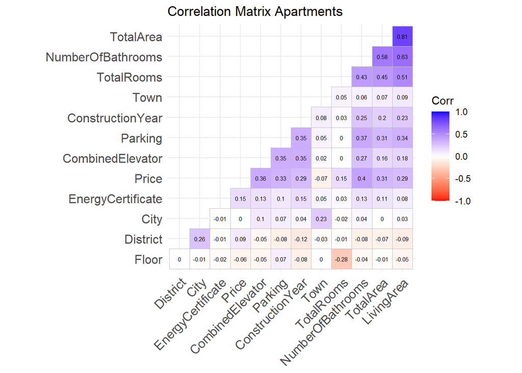

```r
# Check that the correlation matrix does not contain NA/NaN values
if (any(is.na(correlation_matrix))) {
  stop("The correlation matrix contains NA/NaN. Please check the data.")
}

# Generate a heatmap for the correlation matrix
ggcorrplot(correlation_matrix,
           hc.order = TRUE,
           type = "lower",
           lab = TRUE,
           lab_size = 2,
           colors = c("red", "white", "blue"),
           title = "Correlation Matrix Apartments",
           ggtheme = theme_minimal())
```

```r
# Convert factors to numeric values for houses
processed_data <- dataset_house_cleaned %>%
  mutate(across(where(is.factor), ~ as.numeric(as.factor(.))))  # Convert factors to numeric values

# Select numeric columns
all_numeric_vars <- processed_data %>%
  select(where(is.numeric))

# Remove constant columns (zero variance)
all_numeric_vars <- all_numeric_vars %>%
  select(where(~ var(., na.rm = TRUE) > 0))

# Calculate the correlation matrix (handling missing values)
correlation_matrix <- cor(all_numeric_vars, use = "pairwise.complete.obs")

correlation_matrix
```

```
##                         Price     District        City         Town
## Price              1.00000000  0.189710441 0.069910398 -0.046721857
## District           0.18971044  1.000000000 0.094773580 -0.081226200
## City               0.06991040  0.094773580 1.000000000  0.189459535
## Town              -0.04672186 -0.081226200 0.189459535  1.000000000
## EnergyCertificate  0.53039976  0.101761930 0.032505052 -0.016091280
## Parking            0.31238129  0.030552333 0.031594087 -0.018529931
## ConstructionYear   0.51116744  0.038271855 0.044778847 -0.006392187
## TotalArea          0.26793519 -0.002626763 0.031225816  0.001351796
## TotalRooms         0.31731187  0.059391336 0.004727003 -0.006998579
## LivingArea         0.45292216 -0.035052570 0.022972217  0.022087802
## NumberOfBathrooms  0.63192697  0.062370572 0.050881670 -0.018444692
## CombinedElevator   0.04202502  0.002056226 0.011079506 -0.003812334
##                   EnergyCertificate     Parking ConstructionYear    TotalArea
## Price                    0.53039976  0.31238129      0.511167443  0.267935193
## District                 0.10176193  0.03055233      0.038271855 -0.002626763
## City                     0.03250505  0.03159409      0.044778847  0.031225816
## Town                    -0.01609128 -0.01852993     -0.006392187  0.001351796
## EnergyCertificate        1.00000000  0.23151791      0.468693659  0.166831960
## Parking                  0.23151791  1.00000000      0.242761105  0.423962504
## ConstructionYear         0.46869366  0.24276111      1.000000000  0.199322069
## TotalArea                0.16683196  0.42396250      0.199322069  1.000000000
## TotalRooms               0.19324308  0.13964326      0.187135462  0.129913202
## LivingArea               0.27134188  0.25222156      0.354364532  0.398011429
## NumberOfBathrooms        0.45896135  0.30129104      0.478187952  0.253079994
## CombinedElevator         0.01394189  0.02111119      0.018669611  0.012678433
##                     TotalRooms  LivingArea NumberOfBathrooms CombinedElevator
## Price              0.317311870  0.45292216        0.63192697      0.042025025
## District           0.059391336 -0.03505257        0.06237057      0.002056226
## City               0.004727003  0.02297222        0.05088167      0.011079506
## Town              -0.006998579  0.02208780       -0.01844469     -0.003812334
## EnergyCertificate  0.193243078  0.27134188        0.45896135      0.013941888
## Parking            0.139643260  0.25222156        0.30129104      0.021111191
## ConstructionYear   0.187135462  0.35436453        0.47818795      0.018669611
## TotalArea          0.129913202  0.39801143        0.25307999      0.012678433
## TotalRooms         1.000000000  0.29573144        0.32033265      0.016806584
## LivingArea         0.295731443  1.00000000        0.46910465      0.021389423
## NumberOfBathrooms  0.320332654  0.46910465        1.00000000      0.031221973
## CombinedElevator   0.016806584  0.02138942        0.03122197      1.000000000
```

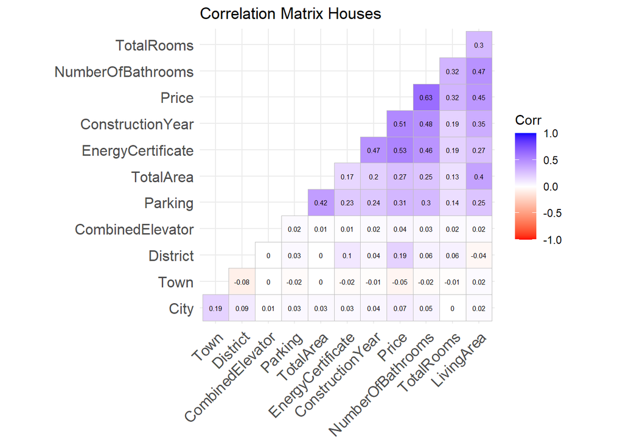

```r
# Check that the correlation matrix does not contain NA/NaN values
if (any(is.na(correlation_matrix))) {
  stop("The correlation matrix contains NA/NaN. Please check the data.")
}

# Generate a heatmap for the correlation matrix
ggcorrplot(correlation_matrix,
           hc.order = TRUE,
           type = "lower",
           lab = TRUE,
           lab_size = 2,
           colors = c("red", "white", "blue"),
           title = "Correlation Matrix Houses",
           ggtheme = theme_minimal())
```

```r
# Convert factors to numeric values for land
processed_data <- dataset_land_cleaned %>%
  mutate(across(where(is.factor), ~ as.numeric(as.factor(.))))  # Convert factors to numeric values

# Select numeric columns
all_numeric_vars <- processed_data %>%
  select(where(is.numeric))

# Remove constant columns (zero variance)
all_numeric_vars <- all_numeric_vars %>%
  select(where(~ var(., na.rm = TRUE) > 0))

# Calculate the correlation matrix (handling missing values)
correlation_matrix <- cor(all_numeric_vars, use = "pairwise.complete.obs")

correlation_matrix
```

```
##                          Price     District         City         Town
## Price              1.000000000  0.079851618  0.071208004 -0.016282080
## District           0.079851618  1.000000000  0.123729208 -0.020641013
## City               0.071208004  0.123729208  1.000000000  0.182383414
## Town              -0.016282080 -0.020641013  0.182383414  1.000000000
## EnergyCertificate  0.001333642 -0.020589150 -0.019699574  0.006947274
## TotalArea          0.024422865 -0.037452047  0.021319458  0.010182827
## CombinedElevator  -0.002077505  0.009203668  0.002624287  0.010397088
##                   EnergyCertificate   TotalArea CombinedElevator
## Price                   0.001333642  0.02442286     -0.002077505
## District               -0.020589150 -0.03745205      0.009203668
## City                   -0.019699574  0.02131946      0.002624287
## Town                    0.006947274  0.01018283      0.010397088
## EnergyCertificate       1.000000000 -0.02757957     -0.002190483
## TotalArea              -0.027579566  1.00000000     -0.010510871
## CombinedElevator       -0.002190483 -0.01051087      1.000000000
```

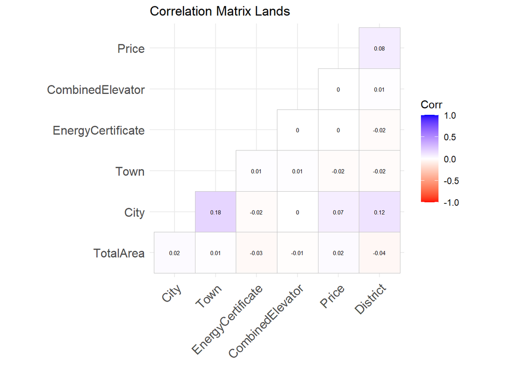

```r
# Check that the correlation matrix does not contain NA/NaN values
if (any(is.na(correlation_matrix))) {
  stop("The correlation matrix contains NA/NaN. Please check the data.")
}

# Generate a heatmap for the correlation matrix
ggcorrplot(correlation_matrix,
           hc.order = TRUE,
           type = "lower",
           lab = TRUE,
           lab_size = 2,
           colors = c("red", "white", "blue"),
           title = "Correlation Matrix Lands",
           ggtheme = theme_minimal())
```

Apartment, has great correlation with price: - NumberOfBathrooms (0.404) - CombinedElevator (0.356) - Parking (0.328) - TotalArea (0.310) - ConstructionYear (0.294) - LivingArea (0.286)

House, has great correlation with price: - NumberOfBathrooms: 0.632 - EnergyCertificate: 0.530 - ConstructionYear: 0.511 - LivingArea: 0.453 - Parking: 0.312 - TotalRooms: 0.317 - TotalArea: 0.268

Land, there are no significant correlations, so undervalued lands can be evaluated based on price and area, as these are the only important variables.

With these graphs, we can demonstrate that there is a correlation between variables.

**Apartments**

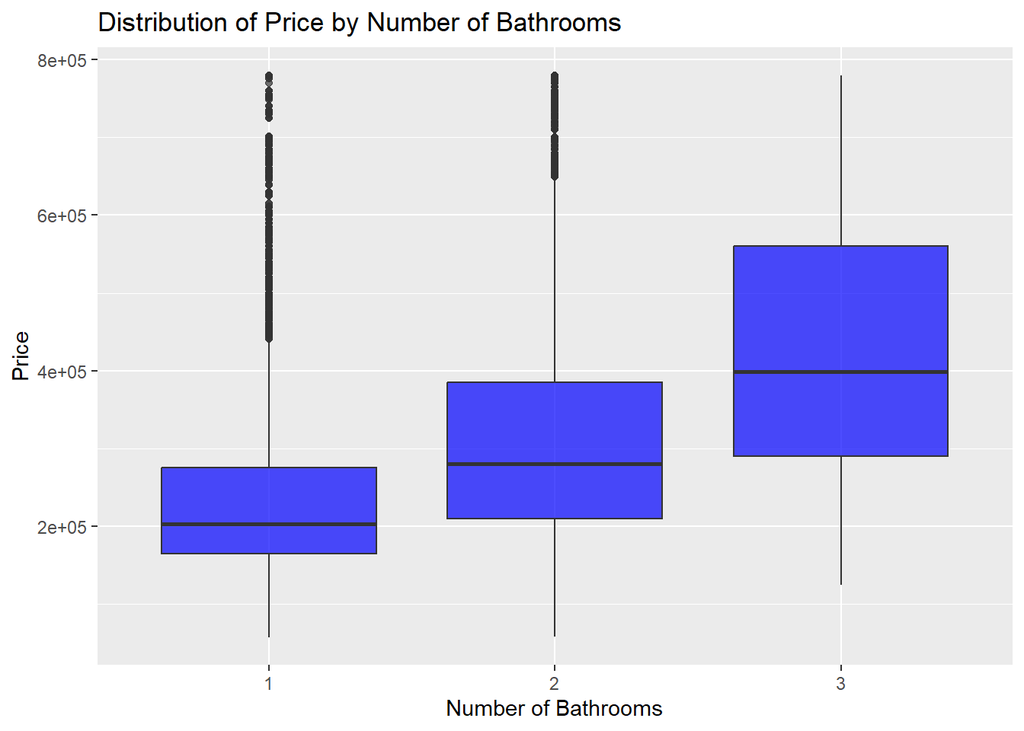

```r
set.seed(42)
data <- dataset_apartment_cleaned

# Relationship 1: NumberOfBathrooms (categorical) vs Price (numerical) - Boxplot
ggplot(data, aes(x = as.factor(NumberOfBathrooms), y = Price)) +
  geom_boxplot(fill = "blue", alpha = 0.7) +
  ggtitle("Distribution of Price by Number of Bathrooms") +
  xlab("Number of Bathrooms") +
  ylab("Price")
```

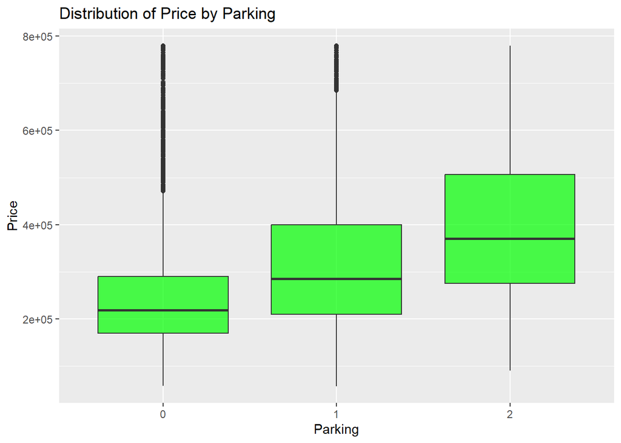

```r
# Relationship 2: Parking (categorical) vs Price (numerical) - Boxplot
ggplot(data, aes(x = as.factor(Parking), y = Price)) +
  geom_boxplot(fill = "green", alpha = 0.7) +
  ggtitle("Distribution of Price by Parking") +
  xlab("Parking") +
  ylab("Price")
```

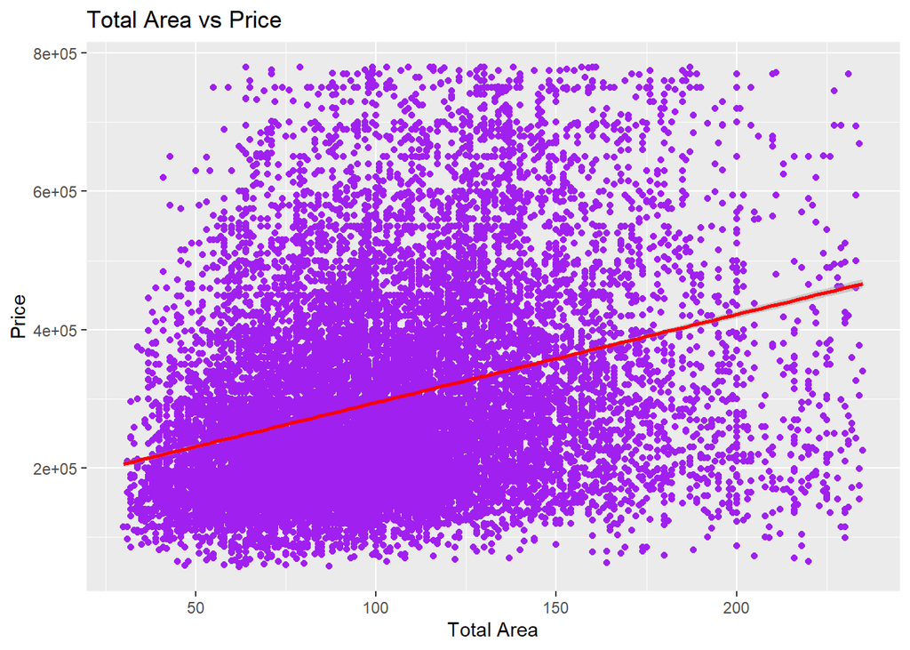

```r
# Relationship 3: TotalArea (numerical) vs Price (numerical) - Linear Regression
ggplot(data, aes(x = TotalArea, y = Price)) +
  geom_point(color = "purple") +
  geom_smooth(method = "lm", color = "red") +
  ggtitle("Total Area vs Price") +
  xlab("Total Area") +
  ylab("Price")
```

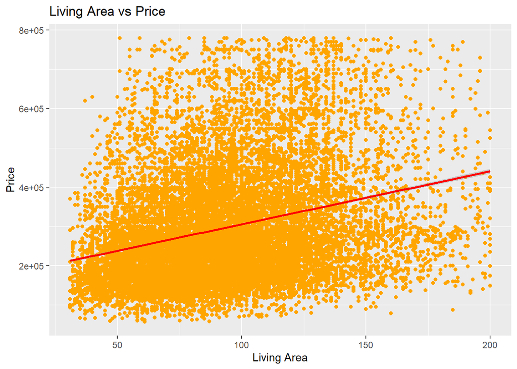

```r
# Relationship 4: LivingArea (numerical) vs Price (numerical) - Linear Regression
ggplot(data, aes(x = LivingArea, y = Price)) +
  geom_point(color = "orange") +
  geom_smooth(method = "lm", color = "red") +
  ggtitle("Living Area vs Price") +
  xlab("Living Area") +
  ylab("Price")
```

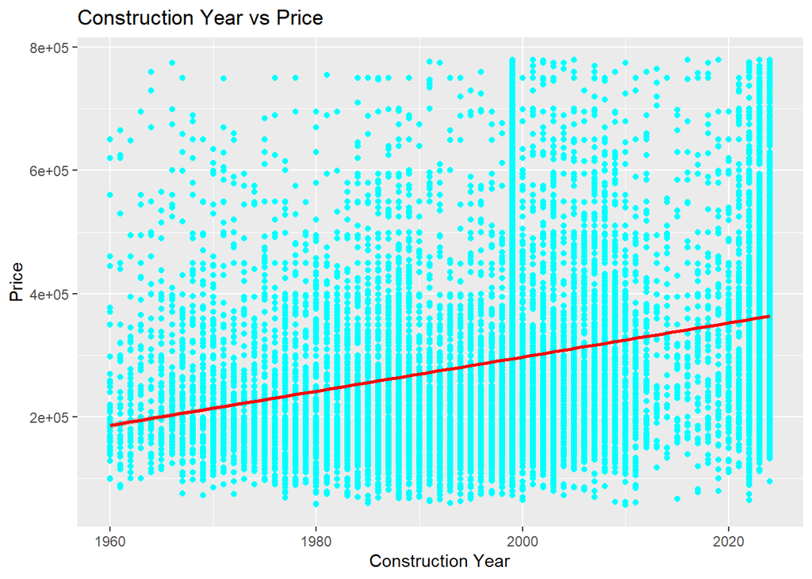

```r
# Relationship 5: ConstructionYear (numerical) vs Price (numerical) - Linear Regression
ggplot(data, aes(x = ConstructionYear, y = Price)) +
  geom_point(color = "cyan") +
  geom_smooth(method = "lm", color = "red") +
  ggtitle("Construction Year vs Price") +
  xlab("Construction Year") +
  ylab("Price")
```

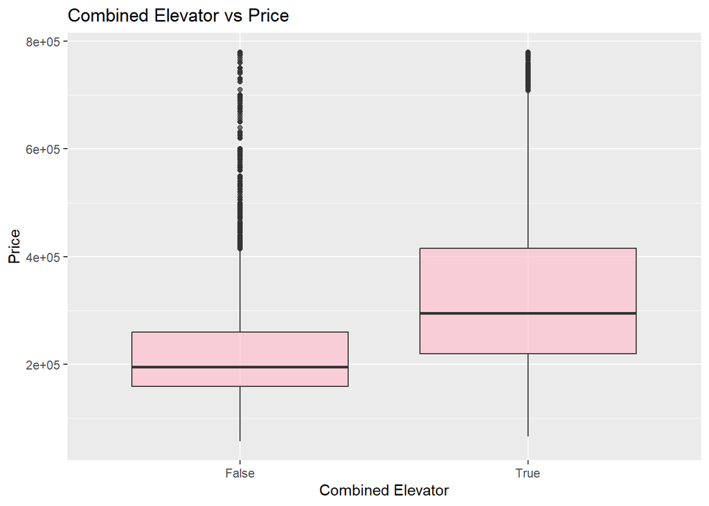

```r
# Relationship 6: CombinedElevator (categorical) vs Price (numerical) - Boxplot
ggplot(data, aes(x = as.factor(CombinedElevator), y = Price)) +
  geom_boxplot(fill = "pink", alpha = 0.7) +
  ggtitle("Combined Elevator vs Price") +
  xlab("Combined Elevator") +
  ylab("Price")
```

**Houses**

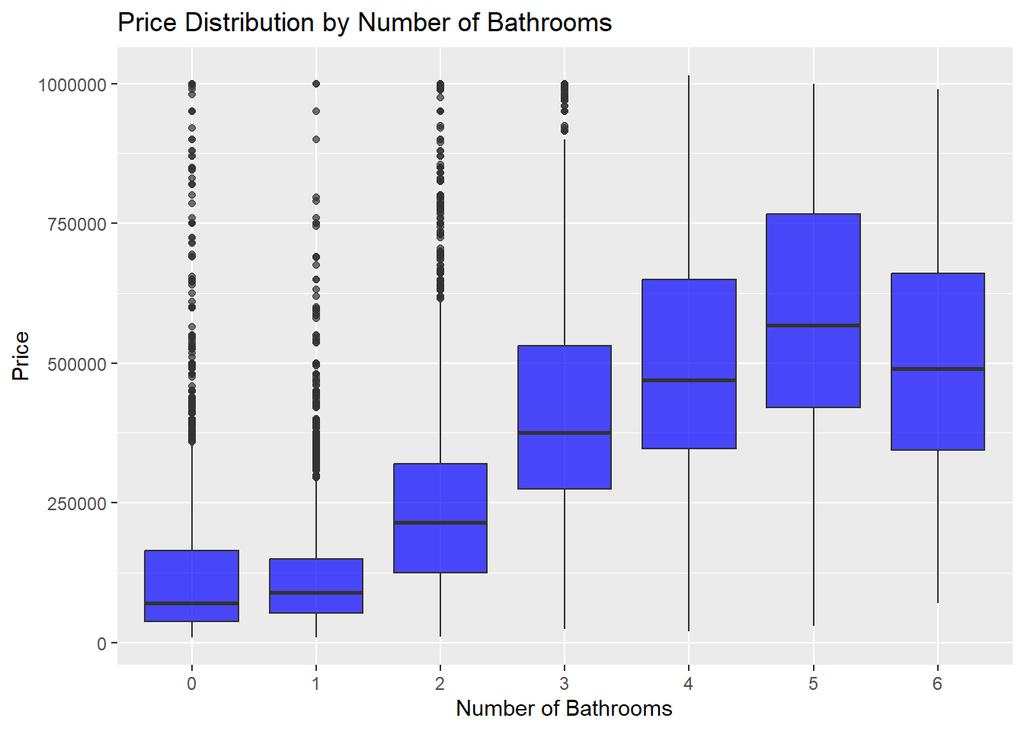

```r
set.seed(42)
data <- dataset_house_cleaned

# Relationship 1: NumberOfBathrooms (categorical) vs Price (Boxplot)
ggplot(data, aes(x = as.factor(NumberOfBathrooms), y = Price)) +
  geom_boxplot(fill = "blue", alpha = 0.7) +
  ggtitle("Price Distribution by Number of Bathrooms") +
  xlab("Number of Bathrooms") +
  ylab("Price")
```

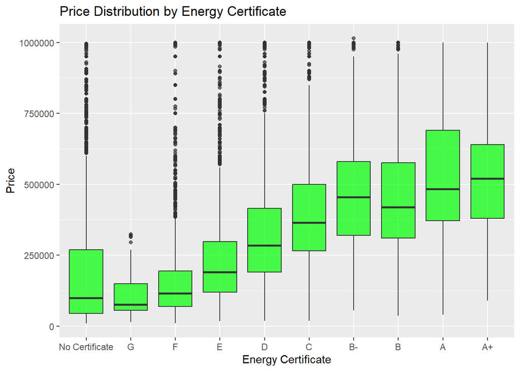

```r
# Relationship 2: EnergyCertificate (categorical) vs Price (Boxplot)
ggplot(data, aes(x = as.factor(EnergyCertificate), y = Price)) +
  geom_boxplot(fill = "green", alpha = 0.7) +
  ggtitle("Price Distribution by Energy Certificate") +
  xlab("Energy Certificate") +
  ylab("Price")
```

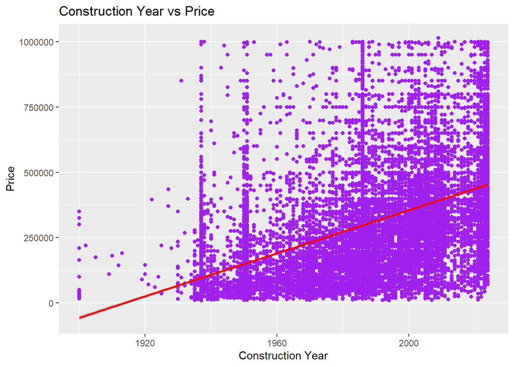

```r
# Relationship 3: ConstructionYear (numeric) vs Price (Linear Regression)
ggplot(data, aes(x = ConstructionYear, y = Price)) +
  geom_point(color = "purple") +
  geom_smooth(method = "lm", color = "red") +
  ggtitle("Construction Year vs Price") +
  xlab("Construction Year") +
  ylab("Price")
```

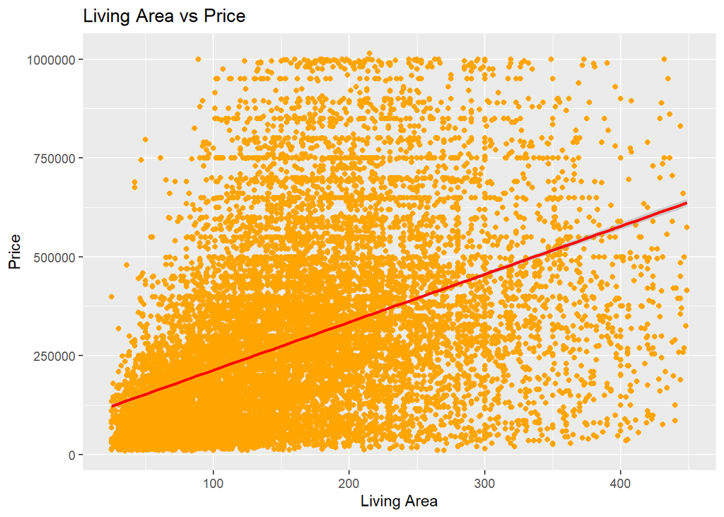

```r
# Relationship 4: LivingArea (numeric) vs Price (Linear Regression)
ggplot(data, aes(x = LivingArea, y = Price)) +
  geom_point(color = "orange") +
  geom_smooth(method = "lm", color = "red") +
  ggtitle("Living Area vs Price") +
  xlab("Living Area") +
  ylab("Price")
```

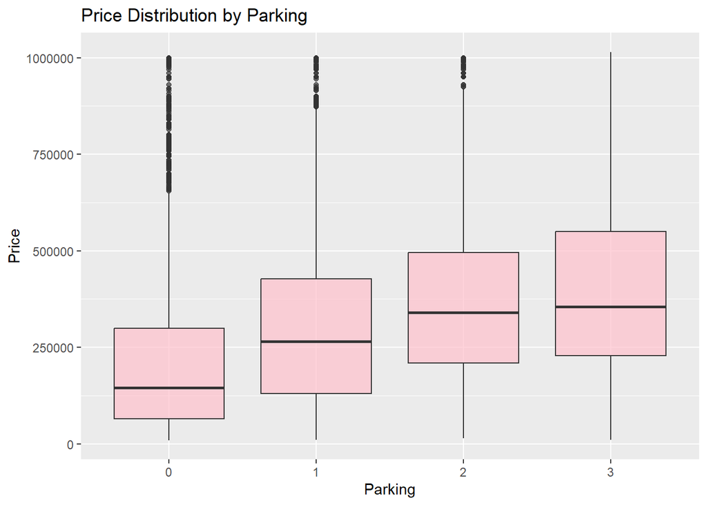

```r
# Relationship 5: Parking (categorical) vs Price (Boxplot)
ggplot(data, aes(x = as.factor(Parking), y = Price)) +
  geom_boxplot(fill = "pink", alpha = 0.7) +
  ggtitle("Price Distribution by Parking") +
  xlab("Parking") +
  ylab("Price")
```

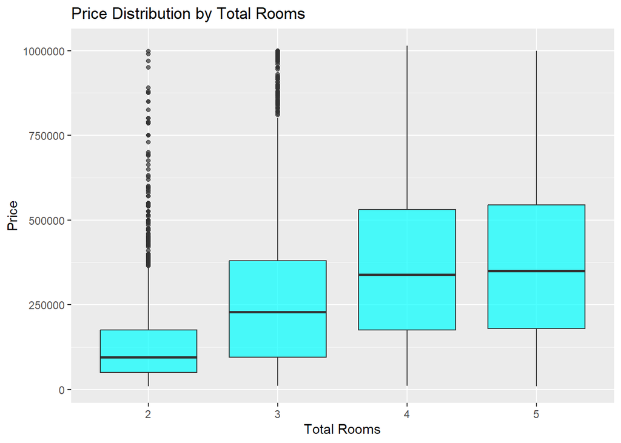

```r
# Relationship 6: TotalRooms (discrete numeric) vs Price (Boxplot)
ggplot(data, aes(x = as.factor(TotalRooms), y = Price)) +
  geom_boxplot(fill = "cyan", alpha = 0.7) +
  ggtitle("Price Distribution by Total Rooms") +
  xlab("Total Rooms") +
  ylab("Price")
```

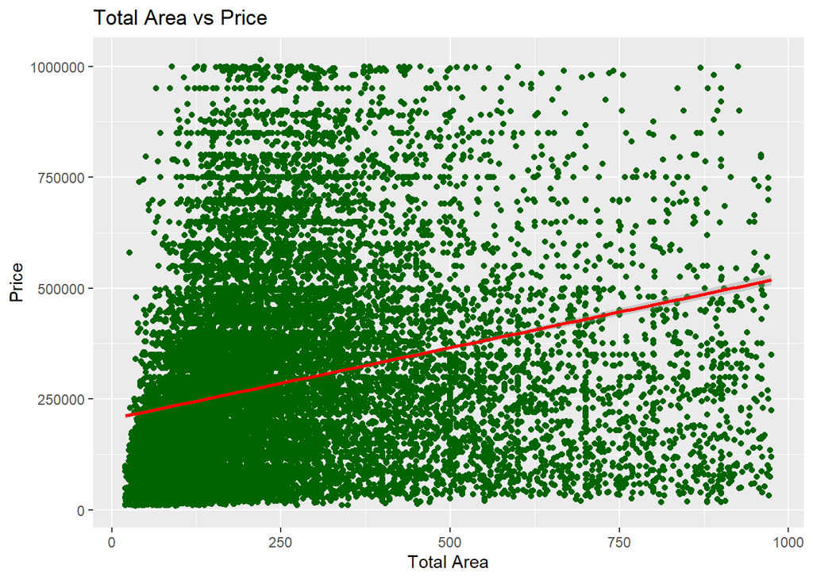

```r
# Relationship 7: TotalArea (numeric) vs Price (Linear Regression)
ggplot(data, aes(x = TotalArea, y = Price)) +
  geom_point(color = "darkgreen") +
  geom_smooth(method = "lm", color = "red") +
  ggtitle("Total Area vs Price") +
  xlab("Total Area") +
  ylab("Price")
```

**Lands**

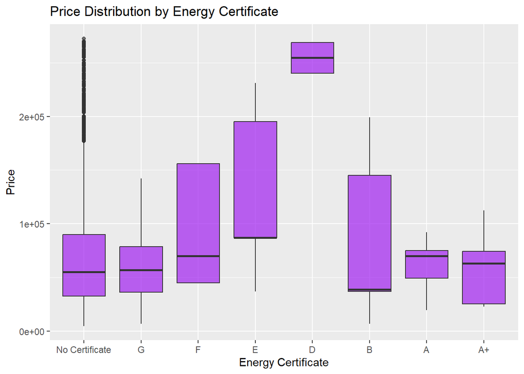

```r
set.seed(42)
data <- dataset_land_cleaned

# Relationship 1: EnergyCertificate (categorical) vs Price (Boxplot)
ggplot(data, aes(x = EnergyCertificate, y = Price)) +
  geom_boxplot(fill = "purple", alpha = 0.7) +
  ggtitle("Price Distribution by Energy Certificate") +
  xlab("Energy Certificate") +
  ylab("Price")
```

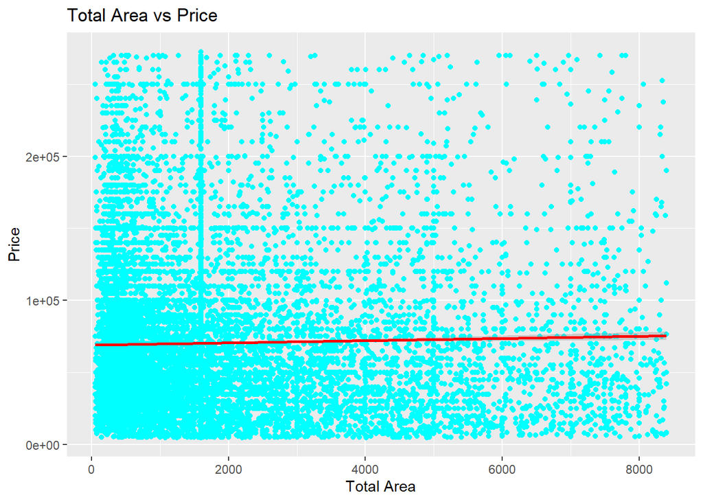

```r
# Relationship 2: TotalArea (numeric) vs Price (Linear Regression)
ggplot(data, aes(x = TotalArea, y = Price)) +
  geom_point(color = "cyan") +
  geom_smooth(method = "lm", color = "red") +
  ggtitle("Total Area vs Price") +
  xlab("Total Area") +
  ylab("Price")
```

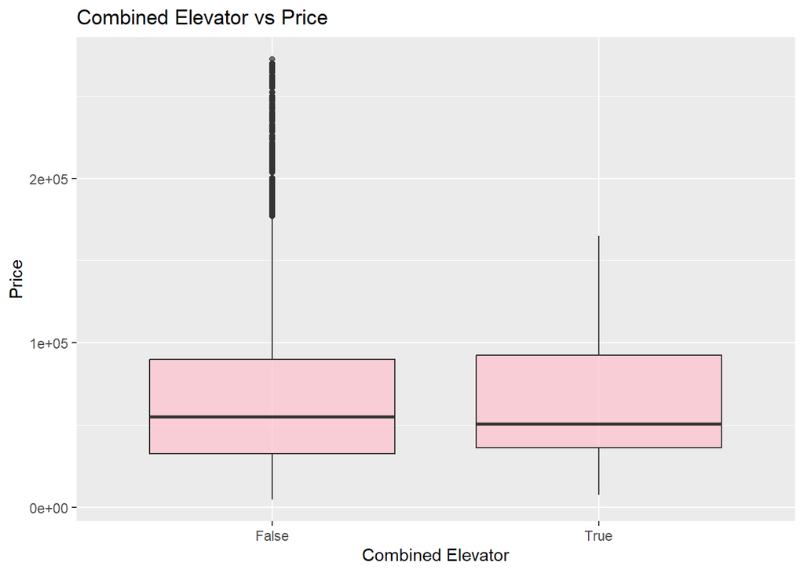

```r
# Relationship 3: CombinedElevator (numeric) vs Price (Linear Regression)
ggplot(data, aes(x = as.factor(CombinedElevator), y = Price)) +
  geom_boxplot(fill = "pink", alpha = 0.7) +
  ggtitle("Combined Elevator vs Price") +
  xlab("Combined Elevator") +
  ylab("Price")
```

We can see how Land has almost no correlation with any variable.

In the second section, the characteristics of homes with a high price will be estimated, and a search will be made for those homes with similar properties and a lower price.

## Second Subquestion

**What are the common characteristics of homes with high prices? How can we identify similar residences that are undervalued?**

### First Method

**Apartments**

For the previous study, we know that the characteristics most related to the price of apartments are:

Apartment, high correlation with the price: - NumberOfBathrooms (0.404) - CombinedElevator (0.356) - Parking (0.328) - TotalArea (0.310) - ConstructionYear (0.294) - LivingArea (0.286)

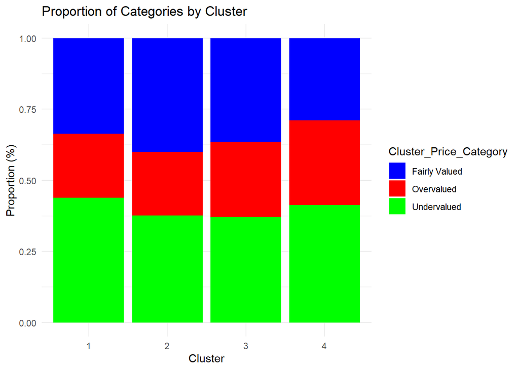

```r
# 2. Initial Predictive Model
price_model <- lm(Price ~ TotalArea + LivingArea + Parking +
                  ConstructionYear + NumberOfBathrooms + CombinedElevator,
                  data = dataset_apartment_cleaned)

# 3. Prediction and residuals calculation
dataset_apartment_cleaned <- dataset_apartment_cleaned %>%
  mutate(
    Predicted_Price = predict(price_model, dataset_apartment_cleaned),
    Predicted_Error = residuals(price_model), # Model errors
    Lower_Bound = Predicted_Price - 1.96 * sd(Predicted_Error), # Lower bound
    Upper_Bound = Predicted_Price + 1.96 * sd(Predicted_Error)  # Upper bound
  )

# 4. Refine undervalued definition with confidence intervals
dataset_apartment_cleaned <- dataset_apartment_cleaned %>%
  mutate(
    Price_Category = case_when(
      Price < Lower_Bound ~ "Undervalued",
      Price > Upper_Bound ~ "Overvalued",
      TRUE ~ "Fairly Valued"
    )
  )

# 5. Compare actual and predicted prices with ratios
dataset_apartment_cleaned <- dataset_apartment_cleaned %>%
  mutate(
    Price_Ratio = Price / Predicted_Price,
    Refined_Price_Category = case_when(
      Price_Ratio < 0.8 ~ "Undervalued",
      Price_Ratio > 1.2 ~ "Overvalued",
      TRUE ~ "Fairly Valued"
    )
  )

# 6. Clustering analysis by similar characteristics
cluster_data <- dataset_apartment_cleaned %>%
  select(TotalArea, LivingArea, TotalRooms, NumberOfBathrooms, ConstructionYear, Parking) %>%
  scale()

set.seed(123)
kmeans_result <- kmeans(cluster_data, centers = 4)

# Add clusters to the main dataset
dataset_apartment_cleaned <- dataset_apartment_cleaned %>%
  mutate(Cluster = kmeans_result$cluster)

# Calculate average prices by cluster
cluster_summary <- dataset_apartment_cleaned %>%
  group_by(Cluster) %>%
  summarise(
    Avg_Price = mean(Price, na.rm = TRUE),
    Avg_Predicted = mean(Predicted_Price, na.rm = TRUE)
  )

# Ensure the join is correct
dataset_apartment_cleaned <- dataset_apartment_cleaned %>%
  left_join(cluster_summary, by = "Cluster")

# Validate that necessary columns are present
if (!"Avg_Price" %in% names(dataset_apartment_cleaned)) {
  stop("Error: 'Avg_Price' was not correctly added to the main dataset.")
}

# Identify undervalued apartments by cluster
dataset_apartment_cleaned <- dataset_apartment_cleaned %>%
  mutate(
    Cluster_Price_Category = case_when(
      Price < 0.8 * Avg_Price ~ "Undervalued",
      Price > 1.2 * Avg_Price ~ "Overvalued",
      TRUE ~ "Fairly Valued"
    )
  )

# 7. Visualizations
# Bar plot of the distribution of categories
# Proportion of categories within each cluster
dataset_apartment_cleaned %>%
  group_by(Cluster, Cluster_Price_Category) %>%
  summarise(Count = n()) %>%
  mutate(Percentage = Count / sum(Count) * 100) %>%
  ggplot(aes(x = as.factor(Cluster), y = Percentage, fill = Cluster_Price_Category)) +
  geom_bar(stat = "identity", position = "fill") +
  ggtitle("Proportion of Categories by Cluster") +
  xlab("Cluster") +
  ylab("Proportion (%)") +
  theme_minimal() +
  scale_fill_manual(values = c("blue", "red", "green"))
```

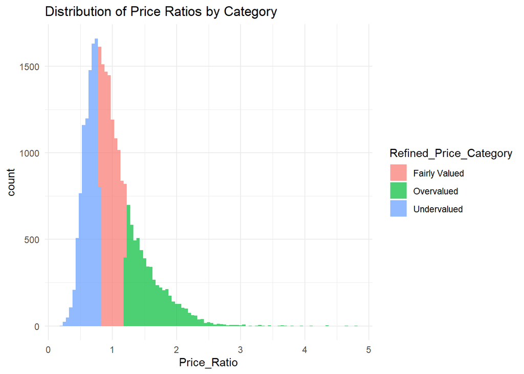

```r
ggplot(dataset_apartment_cleaned, aes(x = Price_Ratio, fill = Refined_Price_Category)) +
  geom_histogram(binwidth = 0.05, alpha = 0.7) +
  ggtitle("Distribution of Price Ratios by Category") +
  theme_minimal()
```